# **Описание проекта**

В нашем распоряжении имеется **информация** о деловой активности интернет-магазина компьютерных игр «Стримчик» с 1985 года по 2016 год.

В рамках проекта мы имеем **данные** о продажах игр, оценках пользователей и экспертов, жанрах и платформах, а также о рейтинге игр.

**Целью** проекта является определение факторов, оказывающих наибольшее влияние на успешность игры.

**Решение**, выработанное в рамках проекта, позволит компании спланировать рекламные кампании, фокусируясь на наиболее востребованных продуктах, в целях **увеличения объёмов продаж и максимизации прибыли**.

Для этого необходимо:

1. Рассчитать **дополнительные параметры:**

1.1. Суммарные продажи во всех регионах.

1. Ответить на ряд **вопросов:**

2.1. Сколько игр выпускалось в разные годы. Важны ли данные за все периоды?

2.2. Как менялись продажи по платформам? За какой характерный срок появляются новые и исчезают старые платформы?

2.3. Как определить актуальный период, пригодный для построения прогноза на 2017 год.

2.4. Какие платформы лидируют по продажам, растут или падают? Можно ли выбрать несколько потенциально прибыльных платформ?

2.5. Как влияют на продажи внутри одной популярной платформы отзывы пользователей и критиков? Как можно соотнести полученные выводы с продажами игр на других платформах?

2.6. Что можно сказать об общем распределении игр по жанрам? Что можно сказать о самых прибыльных жанрах? Выделяются ли жанры с высокими и низкими продажами?

1. **Определить** для пользователя каждого региона (NA, EU, JP):

3.1. Самые популярные платформы (топ-5) (с описанием различий в долях продаж).

3.2. Самые популярные жанры (топ-5) (с пояснением разницы).

3.3. Влияние рейтинга ESRB на продажи в отдельном регионе.

1. Подтвердить или опровергнуть следующие **гипотезы:**

4.1. Средние пользовательские рейтинги платформ Xbox One и PC одинаковые.

4.2. Средние пользовательские рейтинги жанров Action и Sports разные.

Работу над проектом будем осуществлять в следующем **порядке:**

1. Чтение данных, их изучение, поиск аномальных и пропущенных значений в данных.
1. Предварительная обработка данных, расчёт дополнительных парамтеров.
1. Анализ данных.
1. Построение портрета пользователя каждого региона.
1. Построение гипотез и их проверка.
1. Общий вывод по проекту.

# Этап 1. Чтение данных, их изучение, поиск аномальных и пропущенных значений в данных.

## Этап 1.1. Ипорт библиотек, чтение файлов.

Импортируем необходимые библиотеки.

```python
import pandas as pd
import warnings
warnings.filterwarnings('ignore')
import matplotlib.pyplot as plt
import numpy as np
import math
from scipy import stats as st
```

Считаем набор данных, создаим DataFrame.

```python
df = pd.read_csv('/games.csv')
```

Для получения информации о df напишем функцию, принимающую на вход df, а на выходе предоставляющую общую информацию о df: первые 10 строк, информацию о df, его размер, наличие пропущенных значений и дубликатов, а также уникальные значения в каждом поле.

```python
def df_info(df):
    print('Первые 10 строк DF')
    display(df.head(10))
    print('Общая информация о DF')
    display(df.info())
    print('Размер df:', df.shape)
    print()
    print('Пропуски в df')
    display(df.isna().sum())
    print('Количество дубликатов в df:', df.duplicated().sum())
    print()
    for col in df.columns:
        print('*** Поле', col + ': уникальные значения ***')
        display(df[col].value_counts())
```

```python
df_info(df)
```

```
Первые 10 строк DF
```

|  | Name | Platform | Year_of_Release | Genre | NA_sales | EU_sales | JP_sales | Other_sales | Critic_Score | User_Score | Rating |
| --- | --- | --- | --- | --- | --- | --- | --- | --- | --- | --- | --- |
| 0 | Wii Sports | Wii | 2006.0 | Sports | 41.36 | 28.96 | 3.77 | 8.45 | 76.0 | 8 | E |
| 1 | Super Mario Bros. | NES | 1985.0 | Platform | 29.08 | 3.58 | 6.81 | 0.77 | NaN | NaN | NaN |
| 2 | Mario Kart Wii | Wii | 2008.0 | Racing | 15.68 | 12.76 | 3.79 | 3.29 | 82.0 | 8.3 | E |
| 3 | Wii Sports Resort | Wii | 2009.0 | Sports | 15.61 | 10.93 | 3.28 | 2.95 | 80.0 | 8 | E |
| 4 | Pokemon Red/Pokemon Blue | GB | 1996.0 | Role-Playing | 11.27 | 8.89 | 10.22 | 1.00 | NaN | NaN | NaN |
| 5 | Tetris | GB | 1989.0 | Puzzle | 23.20 | 2.26 | 4.22 | 0.58 | NaN | NaN | NaN |
| 6 | New Super Mario Bros. | DS | 2006.0 | Platform | 11.28 | 9.14 | 6.50 | 2.88 | 89.0 | 8.5 | E |
| 7 | Wii Play | Wii | 2006.0 | Misc | 13.96 | 9.18 | 2.93 | 2.84 | 58.0 | 6.6 | E |
| 8 | New Super Mario Bros. Wii | Wii | 2009.0 | Platform | 14.44 | 6.94 | 4.70 | 2.24 | 87.0 | 8.4 | E |
| 9 | Duck Hunt | NES | 1984.0 | Shooter | 26.93 | 0.63 | 0.28 | 0.47 | NaN | NaN | NaN |

```
Общая информация о DF
<class 'pandas.core.frame.DataFrame'>
RangeIndex: 16715 entries, 0 to 16714
Data columns (total 11 columns):
 #   Column           Non-Null Count  Dtype
---  ------           --------------  -----
 0   Name             16713 non-null  object
 1   Platform         16715 non-null  object
 2   Year_of_Release  16446 non-null  float64
 3   Genre            16713 non-null  object
 4   NA_sales         16715 non-null  float64
 5   EU_sales         16715 non-null  float64
 6   JP_sales         16715 non-null  float64
 7   Other_sales      16715 non-null  float64
 8   Critic_Score     8137 non-null   float64
 9   User_Score       10014 non-null  object
 10  Rating           9949 non-null   object
dtypes: float64(6), object(5)
memory usage: 1.4+ MB
```

```
None
```

```
Размер df: (16715, 11)

Пропуски в df
```

```
Name                  2
Platform              0
Year_of_Release     269
Genre                 2
NA_sales              0
EU_sales              0
JP_sales              0
Other_sales           0
Critic_Score       8578
User_Score         6701
Rating             6766
dtype: int64
```

```
Количество дубликатов в df: 0

*** Поле Name: уникальные значения ***
```

```
Need for Speed: Most Wanted                                                                                      12
Ratatouille                                                                                                       9
FIFA 14                                                                                                           9
LEGO Marvel Super Heroes                                                                                          9
Madden NFL 07                                                                                                     9
                                                                                                                 ..
DS Nishimura Kyotaro Suspense 2 Shin Tantei Series: Kanazawa Hakodate - Gokkan no Kyoukoku - Fukushuu no Kage     1
Imagine: Fashion Stylist                                                                                          1
Brute Force                                                                                                       1
Sega Arcade Gallery                                                                                               1
Thomas the Tank Engine & Friends                                                                                  1
Name: Name, Length: 11559, dtype: int64
```

```
*** Поле Platform: уникальные значения ***
```

```
PS2     2161
DS      2151
PS3     1331
Wii     1320
X360    1262
PSP     1209
PS      1197
PC       974
XB       824
GBA      822
GC       556
3DS      520
PSV      430
PS4      392
N64      319
XOne     247
SNES     239
SAT      173
WiiU     147
2600     133
NES       98
GB        98
DC        52
GEN       29
NG        12
WS         6
SCD        6
3DO        3
TG16       2
PCFX       1
GG         1
Name: Platform, dtype: int64
```

```
*** Поле Year_of_Release: уникальные значения ***
```

```
2008.0    1427
2009.0    1426
2010.0    1255
2007.0    1197
2011.0    1136
2006.0    1006
2005.0     939
2002.0     829
2003.0     775
2004.0     762
2012.0     653
2015.0     606
2014.0     581
2013.0     544
2016.0     502
2001.0     482
1998.0     379
2000.0     350
1999.0     338
1997.0     289
1996.0     263
1995.0     219
1994.0     121
1993.0      62
1981.0      46
1992.0      43
1991.0      41
1982.0      36
1986.0      21
1989.0      17
1983.0      17
1990.0      16
1987.0      16
1988.0      15
1985.0      14
1984.0      14
1980.0       9
Name: Year_of_Release, dtype: int64
```

```
*** Поле Genre: уникальные значения ***
```

```
Action          3369
Sports          2348
Misc            1750
Role-Playing    1498
Shooter         1323
Adventure       1303
Racing          1249
Platform         888
Simulation       873
Fighting         849
Strategy         683
Puzzle           580
Name: Genre, dtype: int64
```

```
*** Поле NA_sales: уникальные значения ***
```

```
0.00    4508
0.02     576
0.03     561
0.04     549
0.01     545
        ...
4.98       1
4.21       1
6.82       1
5.05       1
9.00       1
Name: NA_sales, Length: 402, dtype: int64
```

```
*** Поле EU_sales: уникальные значения ***
```

```
0.00    5870
0.01    1494
0.02    1308
0.03     926
0.04     709
        ...
3.59       1
4.02       1
2.24       1
2.27       1
3.75       1
Name: EU_sales, Length: 307, dtype: int64
```

```
*** Поле JP_sales: уникальные значения ***
```

```
0.00    10514
0.02      741
0.01      706
0.03      546
0.04      397
        ...
1.16        1
2.12        1
7.20        1
2.17        1
6.50        1
Name: JP_sales, Length: 244, dtype: int64
```

```
*** Поле Other_sales: уникальные значения ***
```

```
0.00    6601
0.01    3464
0.02    1618
0.03     926
0.04     654
        ...
0.96       1
1.93       1
0.97       1
1.37       1
1.06       1
Name: Other_sales, Length: 155, dtype: int64
```

```
*** Поле Critic_Score: уникальные значения ***
```

```
70.0    256
71.0    254
75.0    245
78.0    240
73.0    238
       ...
20.0      3
17.0      1
22.0      1
13.0      1
21.0      1
Name: Critic_Score, Length: 82, dtype: int64
```

```
*** Поле User_Score: уникальные значения ***
```

```
tbd    2424
7.8     324
8       290
8.2     282
8.3     254
       ...
0.2       2
0.6       2
1         2
9.7       1
0         1
Name: User_Score, Length: 96, dtype: int64
```

```
*** Поле Rating: уникальные значения ***
```

```
E       3990
T       2961
M       1563
E10+    1420
EC         8
K-A        3
RP         3
AO         1
Name: Rating, dtype: int64
```

# Вывод по этапу 1.

На данном этапе были **импортированы необходимые для работы библиотеки**, а также был **прочитан и проанализирован предложенный набор данных.**

Для получения информации о df была написана соответствующая функция.

DF состоит из **16 715 строк и 11 полей**, из которых:

- 5 полей - категориальные (тип - object);
- 6 полей - дробные числовые значения (тип - float).

В DF **отсутствуют дубликаты**, однако наблюдаются **пропущенные значения:**

- поле Name - 2 пропущенных значения;
- поле Year_of_Release - 269 пропущенных значений;
- поле Genrе - 2 пропущенных значения;
- поле Critic_Score - 8 578 пропущенных значений;
- поле User_Score - 6 701 пропущенное значение;
- Rating - 6 766 пропущенных значений.

Отметим особенности набора данных, на которые нужно будет обратить внимание в ходе работы с ним:

1. В поле **Name** есть записи, которые встречаются больше 1 раза. Так как речь идёт о рейтинге игры, изначально упоминание одного наименования более одного раза вызывает вопросы. Стоит проверить, есть ли какие-то различия между записями, где одно название упоминается более 1 раза.
1. В поле **Year_of_Release** даты релиза игр приведены в дробном значении (тип float), их будет корректнее привести к типу int.
1. В поле **User_Score**, описывающий оценку игры со стороны игроков, данные записаны в типе object, их нужно свести к типу float.
1. В полях **NA_sales, JP_sales, EU_sales и Other_sales**, которые описывают продажи в Серевной Америке, Европе, Японии и других странах соответственно (в миллионах долларов), содержится большое количество записей с объёмом продаж, равным нулю. С учётом того, что данные приведены в типе float с округлением до двух знаков до запятой, мы увидим объём продаж, если он равен или превышает 10 000 долларов. Теоретически, объём продаж может быть ниже 10 000 долларов, и в таком случае он будет записан как 0.00, хотя это не будет означать, что продаж по этой игре не было. С другой стороны, теоретически игра действительно могла просто не продаваться, так как ещё до релиза её могли разгромить критики. В любом случае, независимо от гипотезы, стоит посмотреть на рейтинг игр с объёмом продаж 0.00 миллионов долларов: если рейтинг низкий - мы, скорее всего, имеем дело с играми никзкого качества, если рейтинг высокий - данные о продажах данных игр отсутствуют.
1. В поле **User_Score** присутствует значение tbd (2 424 записи). Нужно их проанализировать и выяснить их природу.

# Этап 2. Предварительная обработка данных, расчёт дополнительных парамтеров.

Предварительную обработку данных будем проводить по следующему сценарию:

1. Преобразование типов данных.
1. Обработка аномальных значений.
1. Обработка пропущенных значений.
1. Расчёт дополнительных параметров.

## Этап 2.1. Преобразование типов данных.

На этапе 1 мы пришли к необходимости преобразования значений поля Year_of_Release в тип данных int, так как говорить о дате удобнее, когда она не содержит значений после запятой (да их там и быть не может), и значений поля User_Score в тип float.

Однако учитывая тот факт, что в поле Year_of_Release содержатся пропущенные значения, к простому int данные привести невозможно. Поэтому приведём данные к типу Int 64, приведение к которому игнорирует наличие пропущенных значений.

Также необходимо преобразовать данные в поле User_Score, однако в данном поле, помимо пропущенных значений и значений типа object, есть значение tbd, которое будет мешать преобразованию с помощью метода astype. Поэтому преобразованиие типа данных в поле User_Score проведём на этапе обработки аномальных значений в этом поле.

Сначала посмотрим на наши данные до преобразования.

```python
df.head(10)
```

|  | Name | Platform | Year_of_Release | Genre | NA_sales | EU_sales | JP_sales | Other_sales | Critic_Score | User_Score | Rating |
| --- | --- | --- | --- | --- | --- | --- | --- | --- | --- | --- | --- |
| 0 | Wii Sports | Wii | 2006.0 | Sports | 41.36 | 28.96 | 3.77 | 8.45 | 76.0 | 8 | E |
| 1 | Super Mario Bros. | NES | 1985.0 | Platform | 29.08 | 3.58 | 6.81 | 0.77 | NaN | NaN | NaN |
| 2 | Mario Kart Wii | Wii | 2008.0 | Racing | 15.68 | 12.76 | 3.79 | 3.29 | 82.0 | 8.3 | E |
| 3 | Wii Sports Resort | Wii | 2009.0 | Sports | 15.61 | 10.93 | 3.28 | 2.95 | 80.0 | 8 | E |
| 4 | Pokemon Red/Pokemon Blue | GB | 1996.0 | Role-Playing | 11.27 | 8.89 | 10.22 | 1.00 | NaN | NaN | NaN |
| 5 | Tetris | GB | 1989.0 | Puzzle | 23.20 | 2.26 | 4.22 | 0.58 | NaN | NaN | NaN |
| 6 | New Super Mario Bros. | DS | 2006.0 | Platform | 11.28 | 9.14 | 6.50 | 2.88 | 89.0 | 8.5 | E |
| 7 | Wii Play | Wii | 2006.0 | Misc | 13.96 | 9.18 | 2.93 | 2.84 | 58.0 | 6.6 | E |
| 8 | New Super Mario Bros. Wii | Wii | 2009.0 | Platform | 14.44 | 6.94 | 4.70 | 2.24 | 87.0 | 8.4 | E |
| 9 | Duck Hunt | NES | 1984.0 | Shooter | 26.93 | 0.63 | 0.28 | 0.47 | NaN | NaN | NaN |

Выполним преобразование.

```python
df['Year_of_Release'] = df['Year_of_Release'].astype('Int64')
```

Посмотрим на данные после преобразования.

```python
df.head(10)
```

|  | Name | Platform | Year_of_Release | Genre | NA_sales | EU_sales | JP_sales | Other_sales | Critic_Score | User_Score | Rating |
| --- | --- | --- | --- | --- | --- | --- | --- | --- | --- | --- | --- |
| 0 | Wii Sports | Wii | 2006 | Sports | 41.36 | 28.96 | 3.77 | 8.45 | 76.0 | 8 | E |
| 1 | Super Mario Bros. | NES | 1985 | Platform | 29.08 | 3.58 | 6.81 | 0.77 | NaN | NaN | NaN |
| 2 | Mario Kart Wii | Wii | 2008 | Racing | 15.68 | 12.76 | 3.79 | 3.29 | 82.0 | 8.3 | E |
| 3 | Wii Sports Resort | Wii | 2009 | Sports | 15.61 | 10.93 | 3.28 | 2.95 | 80.0 | 8 | E |
| 4 | Pokemon Red/Pokemon Blue | GB | 1996 | Role-Playing | 11.27 | 8.89 | 10.22 | 1.00 | NaN | NaN | NaN |
| 5 | Tetris | GB | 1989 | Puzzle | 23.20 | 2.26 | 4.22 | 0.58 | NaN | NaN | NaN |
| 6 | New Super Mario Bros. | DS | 2006 | Platform | 11.28 | 9.14 | 6.50 | 2.88 | 89.0 | 8.5 | E |
| 7 | Wii Play | Wii | 2006 | Misc | 13.96 | 9.18 | 2.93 | 2.84 | 58.0 | 6.6 | E |
| 8 | New Super Mario Bros. Wii | Wii | 2009 | Platform | 14.44 | 6.94 | 4.70 | 2.24 | 87.0 | 8.4 | E |
| 9 | Duck Hunt | NES | 1984 | Shooter | 26.93 | 0.63 | 0.28 | 0.47 | NaN | NaN | NaN |

Видим, что данные преобразованы корректно.

## Этап 2.2. Обработка аномальных значений.

На данном этапе обработаем аномальные значения в df. Напомню, что аномальные значения были идентифицированы в следующих полях:

1. Name (есть записи, которые встречаются больше 1 раза).
2. NA_sales, JP_sales, EU_sales и Other_sales (продажи со значением 0.00 млн. долларов).
3. User_Score (значение tbd).

### Этап 2.2.1. Обработка аномальных значений в поле Name.

Чтобы понять, аномальны ли значения в поле Name, которые упоминаются несколько раз, сначала идентифицируем те наименования, которые встречаются в df более 1 раза, а потом изучим эти записи в нашем df.

Для подсчёта количества наименований воспользуемся сводной таблицей.

```python
df.pivot_table(index = 'Name', values = 'Platform', aggfunc = 'count').query('Platform > 1')\
.sort_values('Platform', ascending = False)
```

| Name | Platform |
| --- | --- |
| Need for Speed: Most Wanted | 12 |
| Madden NFL 07 | 9 |
| LEGO Marvel Super Heroes | 9 |
| FIFA 14 | 9 |
| Ratatouille | 9 |
| ... | ... |
| LEGO Soccer Mania | 2 |
| LEGO Racers | 2 |
| LEGO Ninjago: Shadow of Ronin | 2 |
| LEGO City Undercover | 2 |
| uDraw Studio: Instant Artist | 2 |

2805 rows × 1 columns

Видим, что получен список наименований, которые встречаются более 1 раза. Для исследования возьмём признанного лидера в части частоты упоминания в df - Need for Speed: Most Wanted - и посмотрим на строки df, где в поле Name содержится запись об этой игре.

```python
df.query('Name == "Need for Speed: Most Wanted"')
```

|  | Name | Platform | Year_of_Release | Genre | NA_sales | EU_sales | JP_sales | Other_sales | Critic_Score | User_Score | Rating |
| --- | --- | --- | --- | --- | --- | --- | --- | --- | --- | --- | --- |
| 253 | Need for Speed: Most Wanted | PS2 | 2005 | Racing | 2.03 | 1.79 | 0.08 | 0.47 | 82.0 | 9.1 | T |
| 523 | Need for Speed: Most Wanted | PS3 | 2012 | Racing | 0.71 | 1.46 | 0.06 | 0.58 | NaN | NaN | NaN |
| 1190 | Need for Speed: Most Wanted | X360 | 2012 | Racing | 0.62 | 0.78 | 0.01 | 0.15 | 83.0 | 8.5 | T |
| 1591 | Need for Speed: Most Wanted | X360 | 2005 | Racing | 1.00 | 0.13 | 0.02 | 0.10 | 83.0 | 8.5 | T |
| 1998 | Need for Speed: Most Wanted | XB | 2005 | Racing | 0.53 | 0.46 | 0.00 | 0.05 | 83.0 | 8.8 | T |
| 2048 | Need for Speed: Most Wanted | PSV | 2012 | Racing | 0.33 | 0.45 | 0.01 | 0.22 | NaN | NaN | NaN |
| 3581 | Need for Speed: Most Wanted | GC | 2005 | Racing | 0.43 | 0.11 | 0.00 | 0.02 | 80.0 | 9.1 | T |
| 5972 | Need for Speed: Most Wanted | PC | 2005 | Racing | 0.02 | 0.23 | 0.00 | 0.04 | 82.0 | 8.5 | T |
| 6273 | Need for Speed: Most Wanted | WiiU | 2013 | Racing | 0.13 | 0.12 | 0.00 | 0.02 | NaN | NaN | NaN |
| 6410 | Need for Speed: Most Wanted | DS | 2005 | Racing | 0.24 | 0.01 | 0.00 | 0.02 | 45.0 | 6.1 | E |
| 6473 | Need for Speed: Most Wanted | GBA | 2005 | Racing | 0.19 | 0.07 | 0.00 | 0.00 | NaN | 8.3 | E |
| 11715 | Need for Speed: Most Wanted | PC | 2012 | Racing | 0.00 | 0.06 | 0.00 | 0.02 | 82.0 | 8.5 | T |

Таким образом, видим, что аномалий такая практика не содержит: если одна игра в поле Name упоминается несколько раз, значит, эта игра может быть выпущена на разных платформах, также может отличаться год выпуска игры (например, сначала была выпущена оригинальная игра, в последующем - ремастер/ремейк/перезапуск). Следовательно, в этом поле в части обработки аномальных значений предпринимать ничего не будем.

### Этап 2.2.2. Обработка аномальных значений в полях NA_sales, JP_sales, EU_sales и Other_sales.

Напомним, что в этих полях были обнаружены значения продаж, равные 0.00 млн. долларов. Были выдвинуты следующие гипотезы относительно природы аномалии:

1. Продажи не превышают 10 000 долларов: так как данные приведены в типе float в миллионнах долларов с округлением до 2 знаков после запятой, значение будет отлично от 0.00 только в том случае, если продажи превышают или равны 10 000 долларов. В этом случае объём продаж будет указан как 0.01 млн. долларов. В случае, если объём продаж меньше 10 000 долларов, объём продаж будет указан как 0.00 млн. долларов.
1. Продажи действительно равны нулю, так как игра, возможно, оказалась низкого качества и получила отрицательные отзывы критиков.
1. Данные о продажах этих игр попросту отсутствуют.

Для проверки этих гипотез нужно посмотреть на рейтинги таких игр - будем использовать поле Critic_Score.

```python
df.query('NA_sales == 0 and JP_sales == 0 and EU_sales == 0 and Other_sales == 0')
```

|  | Name | Platform | Year_of_Release | Genre | NA_sales | EU_sales | JP_sales | Other_sales | Critic_Score | User_Score | Rating |
| --- | --- | --- | --- | --- | --- | --- | --- | --- | --- | --- | --- |
| 16676 | G1 Jockey 4 2008 | PS3 | 2008 | Sports | 0.0 | 0.0 | 0.0 | 0.0 | NaN | NaN | NaN |
| 16709 | SCORE International Baja 1000: The Official Game | PS2 | 2008 | Racing | 0.0 | 0.0 | 0.0 | 0.0 | NaN | NaN | NaN |

Видим, что в df содержатся записи только о двух играх, для которых продажи во всех регионах составляют 0.00 млн. долларов, при этом у этих игр нет оценок как от критиков, так и от игроков, также им не присвоен рейтинг.

Вероятно, эти данные были некорректно загружены. Эти данные можно проигнорировать ввиду их малочисленности.

В остальных случаях, когда, например, продажи есть в одном регионе, но их нет в другом, ситуацию сложно считать аномальной, так как это нормальная практика на рынке видеоигр, когда игра выпускается для определённого региона и не продаётся в другом.

При этом также следует помнить, что мы имеем дело не с продажами конкретной игры всеми компаниями мира, а с продажами определённых игр определённой компанией, которая может слабо присутствовать в тех или иных регионах.

### Этап 2.2.3. Обработка аномальных значений в поле User_Score.

Напомним, что в этом поле мы выявлили аномальную запись tbd.

Для начала посмотрим, что общего у игр, для которых в поле User_Score указано значение tbd.

```python
df.query('User_Score == "tbd"')
```

|  | Name | Platform | Year_of_Release | Genre | NA_sales | EU_sales | JP_sales | Other_sales | Critic_Score | User_Score | Rating |
| --- | --- | --- | --- | --- | --- | --- | --- | --- | --- | --- | --- |
| 119 | Zumba Fitness | Wii | 2010 | Sports | 3.45 | 2.59 | 0.0 | 0.66 | NaN | tbd | E |
| 301 | Namco Museum: 50th Anniversary | PS2 | 2005 | Misc | 2.08 | 1.35 | 0.0 | 0.54 | 61.0 | tbd | E10+ |
| 520 | Zumba Fitness 2 | Wii | 2011 | Sports | 1.51 | 1.03 | 0.0 | 0.27 | NaN | tbd | T |
| 645 | uDraw Studio | Wii | 2010 | Misc | 1.65 | 0.57 | 0.0 | 0.20 | 71.0 | tbd | E |
| 657 | Frogger's Adventures: Temple of the Frog | GBA | <NA> | Adventure | 2.15 | 0.18 | 0.0 | 0.07 | 73.0 | tbd | E |
| ... | ... | ... | ... | ... | ... | ... | ... | ... | ... | ... | ... |
| 16695 | Planet Monsters | GBA | 2001 | Action | 0.01 | 0.00 | 0.0 | 0.00 | 67.0 | tbd | E |
| 16697 | Bust-A-Move 3000 | GC | 2003 | Puzzle | 0.01 | 0.00 | 0.0 | 0.00 | 53.0 | tbd | E |
| 16698 | Mega Brain Boost | DS | 2008 | Puzzle | 0.01 | 0.00 | 0.0 | 0.00 | 48.0 | tbd | E |
| 16704 | Plushees | DS | 2008 | Simulation | 0.01 | 0.00 | 0.0 | 0.00 | NaN | tbd | E |
| 16706 | Men in Black II: Alien Escape | GC | 2003 | Shooter | 0.01 | 0.00 | 0.0 | 0.00 | NaN | tbd | T |

2424 rows × 11 columns

Вместо этого проанализируем уникальные значения в таких полях, как Platform, Year_of_Release и Genre.

```python
for col in df.query('User_Score == "tbd"').columns:
    if col in ('Platform', 'Year_of_Release', 'Genre'):
        print(col)
        print()
        print(df[col].value_counts())
        print()
```

```
Platform

PS2     2161
DS      2151
PS3     1331
Wii     1320
X360    1262
PSP     1209
PS      1197
PC       974
XB       824
GBA      822
GC       556
3DS      520
PSV      430
PS4      392
N64      319
XOne     247
SNES     239
SAT      173
WiiU     147
2600     133
NES       98
GB        98
DC        52
GEN       29
NG        12
WS         6
SCD        6
3DO        3
TG16       2
PCFX       1
GG         1
Name: Platform, dtype: int64

Year_of_Release

2008    1427
2009    1426
2010    1255
```

[output cut: 36 more lines]

```
Genre

Action          3369
Sports          2348
Misc            1750
Role-Playing    1498
Shooter         1323
Adventure       1303
Racing          1249
Platform         888
Simulation       873
Fighting         849
Strategy         683
Puzzle           580
Name: Genre, dtype: int64
```

Вместе с тем в игровой индустрии есть аббревиатура tbd (To Be Determined), что означает, что какой-то параметр, которому присвоена данная аббревиатура, будет определён позже. Обычно это характерно для дат релиза игр или дат получения оценок критиков или игроков.

Таким образом, приходим к выводу о том, что запись в поле User_Score со значением tbd является аналогом значения Nan. Для преобразования типа данных из object в float и обработки аномальных значений tbd воспользуемся методом Pandas to_numeric. При этом исключения будем преобразовывать в NaN, для этого необходимо в передать параметру errors аргумент coerce: тогда все исключения будут заменены на NaN.

```python
df['User_Score'] = pd.to_numeric(df['User_Score'], errors = 'coerce')
```

## Этап 2.3. Обработка пропущенных значений.

Напомню, что в ходе изучения набора данных были выявлены следующие пропущенные значения:

- поле Name - 2 пропущенных значения;
- поле Year_of_Release - 269 пропущенных значений;
- поле Genrе - 2 пропущенных значения;
- поле Critic_Score - 8 578 пропущенных значений;
- поле User_Score - 6 701 пропущенное значение;
- поле Rating - 6 766 пропущенных значений.

### Этап 2.3.1. Обработка пропущенных значений в поле Name.

В данном поле у нас всего лишь 2 пропущенных значения. Поле Name содержит информацию о названии игры.

Чтобы понять их природу, давайте посмотрим на эти строки.

```python
df[df['Name'].isna()]
```

|  | Name | Platform | Year_of_Release | Genre | NA_sales | EU_sales | JP_sales | Other_sales | Critic_Score | User_Score | Rating |
| --- | --- | --- | --- | --- | --- | --- | --- | --- | --- | --- | --- |
| 659 | NaN | GEN | 1993 | NaN | 1.78 | 0.53 | 0.00 | 0.08 | NaN | NaN | NaN |
| 14244 | NaN | GEN | 1993 | NaN | 0.00 | 0.00 | 0.03 | 0.00 | NaN | NaN | NaN |

Отмечу, что для двух игр, в которых в поле Name содержатся пропуски, характерна дата релиза, равная 1993 году. Вероятно, пропуски образовались в силу того, что для игр с такой старой датой выхода проблематично собирать статистику, или же старые данные удаляются по мере загрузки в хранилище новых данных, если хранилище не рассчитано на хранение очень большого объёма данных.

Также отмечу, что в df в поле Genre имеются 2 пропущенных значения, и их мы также видим в этом срезе.

Заменить эти пропущенные значения эмпирически не представляется возможным, а ввиду малочисленности пропущенных значений в данном поле эти строки можно просто удалить.

Тем самым мы обработаем пропущенные значения в полях Name и Genre.

```python
df = df[df['Name'].notna()]
```

Проверим, удалены ли пропущенные значения в поле Name.

```python
df['Name'].isna().sum()
```

```
0
```

Видим, что пропущенные значения были успешно удалены.

### Этап 2.3.2. Обработка пропущенных значений в поле Year_of_Release.

Напомню, что изначально в этом поле было 269 пропущенных значений. Поле Year_of_Release описывает дату релиза игры.

Посмотрим на строки с пропущенными значениями поля Year_of_Release и попытаемся понять природу пропущенных значений.

```python
df[df['Year_of_Release'].isna()]
```

|  | Name | Platform | Year_of_Release | Genre | NA_sales | EU_sales | JP_sales | Other_sales | Critic_Score | User_Score | Rating |
| --- | --- | --- | --- | --- | --- | --- | --- | --- | --- | --- | --- |
| 183 | Madden NFL 2004 | PS2 | <NA> | Sports | 4.26 | 0.26 | 0.01 | 0.71 | 94.0 | 8.5 | E |
| 377 | FIFA Soccer 2004 | PS2 | <NA> | Sports | 0.59 | 2.36 | 0.04 | 0.51 | 84.0 | 6.4 | E |
| 456 | LEGO Batman: The Videogame | Wii | <NA> | Action | 1.80 | 0.97 | 0.00 | 0.29 | 74.0 | 7.9 | E10+ |
| 475 | wwe Smackdown vs. Raw 2006 | PS2 | <NA> | Fighting | 1.57 | 1.02 | 0.00 | 0.41 | NaN | NaN | NaN |
| 609 | Space Invaders | 2600 | <NA> | Shooter | 2.36 | 0.14 | 0.00 | 0.03 | NaN | NaN | NaN |
| ... | ... | ... | ... | ... | ... | ... | ... | ... | ... | ... | ... |
| 16373 | PDC World Championship Darts 2008 | PSP | <NA> | Sports | 0.01 | 0.00 | 0.00 | 0.00 | 43.0 | NaN | E10+ |
| 16405 | Freaky Flyers | GC | <NA> | Racing | 0.01 | 0.00 | 0.00 | 0.00 | 69.0 | 6.5 | T |
| 16448 | Inversion | PC | <NA> | Shooter | 0.01 | 0.00 | 0.00 | 0.00 | 59.0 | 6.7 | M |
| 16458 | Hakuouki: Shinsengumi Kitan | PS3 | <NA> | Adventure | 0.01 | 0.00 | 0.00 | 0.00 | NaN | NaN | NaN |
| 16522 | Virtua Quest | GC | <NA> | Role-Playing | 0.01 | 0.00 | 0.00 | 0.00 | 55.0 | 5.5 | T |

269 rows × 11 columns

Исследуем поля Platform и Genre как наиболее очевидные с точки зрения их возможного влияния на причину образования пропущенных значений в поле Year_of_Release: посмотрим на уникальные значения в этих полях.

```python
df[df['Year_of_Release'].isna()]['Platform'].value_counts()
```

```
Wii     34
PS2     34
DS      30
X360    30
PS3     25
XB      21
2600    17
PC      17
PSP     16
GC      14
GBA     11
3DS      8
PS       7
N64      3
PSV      1
GB       1
Name: Platform, dtype: int64
```

```python
df[df['Year_of_Release'].isna()]['Genre'].value_counts()
```

```
Action          62
Sports          42
Misc            29
Shooter         27
Racing          23
Role-Playing    17
Simulation      16
Fighting        12
Puzzle          11
Adventure       10
Strategy        10
Platform        10
Name: Genre, dtype: int64
```

Видим, что пропущенные значения в поле Year_of_Release не связаны со значениями полей Platform и Genre: игры с неизвестной даторй релиза выпущенные на разных платформах и имеют разные жанры.

Так как пропущенные значения даты релиза также невозможно заменить эмпирически, удалим из df строки, в которых значения поля Year_of_Release пропущены.

```python
df = df[df['Year_of_Release'].notna()]
```

Проверим, удалены ли пропущенные значения в поле Name.

```python
df['Year_of_Release'].isna().sum()
```

```
0
```

Видим, что пропущенные значения были успешно удалены.

### Этап 2.3.3. Обработка пропущенных значений в поле Genre.

Напомню, что в поле Genre у нас 2 было пропущенных значения, однако их мы удалили на этапе обработки пропущенных значений в поле Name.

### Этап 2.3.4. Обработка пропущенных значений в поле Critic_Score и User_Score.

Так как в целом при резиле игры маловероятно, что оценка от критиков проставлена не будет, вероятно, что данные просто не были получены (возможно, проблема с выгрузками или загрузкой информации из внешних источников).

Пропущенные значения в этом поле можно заменить на медианное значение оценки критиков в зависимости от жанра.

Для этого создадим сводную таблицу, сгруппируем данные по жанрам, посчитаем медианную оценку критиков для каждого из жанров и сформируем из этой таблицы словарь.

```python
dict_median_critic_score = df.pivot_table(index = 'Genre', values = 'Critic_Score', aggfunc = 'median')['Critic_Score']\
.to_dict()
dict_median_critic_score
```

```
{'Action': 68.0,
 'Adventure': 66.0,
 'Fighting': 72.0,
 'Misc': 69.0,
 'Platform': 69.5,
 'Puzzle': 70.0,
 'Racing': 69.0,
 'Role-Playing': 74.0,
 'Shooter': 73.0,
 'Simulation': 70.0,
 'Sports': 75.0,
 'Strategy': 73.0}
```

Далее напишем фукнцию, которая будут принимать на вход строку и заменять пропущенное значение в поле Critic_Score в зависимости от жанра, при этом жанр будет ключом к словарю, а значением по этому ключу будет соответствующая медианная оценка критиков.

```python
def fillna(row):
    if np.isnan(row['Critic_Score']):
        return dict_median_critic_score.get(row['Genre'])
    return row['Critic_Score']
```

Применим функцию и заменим пропущенные значения поля Critic_Score на медианное значение оценки критиков в зависимости от жанра.

```python
df['Critic_Score'] = df.apply(fillna, axis = 1)
```

Проверим, заменены ли пропущенные значения в поле Critic_Score.

```python
df['Critic_Score'].isna().sum()
```

```
0
```

Видим, что пропущенные значения в поле Critic_Score были успешно обработаны.

### Этап 2.3.5. Обработка пропущенных значений в поле User_Score.

Пропущенные значения в этом поле, вероятно, имеют ту же природу, что и в поле Crtitc_Score: данные просто не были получены (возможно, проблема с выгрузками или загрузкой информации из внешних источников).

Обрабатывать пропуски в этом поле будем аналогично: заменим их на медианную оценку игроков в зависимости от жанра.

Порядок действий тот же: создадим словарь и заменим пропуски на медианные значения по словарю.

```python
dict_median_user_score = df.pivot_table(index = 'Genre', values = 'User_Score', aggfunc = 'median')['User_Score']\
.to_dict()
dict_median_user_score
```

```
{'Action': 7.4,
 'Adventure': 7.6,
 'Fighting': 7.6,
 'Misc': 7.1,
 'Platform': 7.7,
 'Puzzle': 7.5,
 'Racing': 7.4,
 'Role-Playing': 7.8,
 'Shooter': 7.4,
 'Simulation': 7.5,
 'Sports': 7.4,
 'Strategy': 7.8}
```

Далее напишем фукнцию, которая будут принимать на вход строку и заменять пропущенное значение в поле User_Score в зависимости от жанра, при этом жанр будет ключом к словарю, а значением по этому ключу будет соответствующая медианная оценка игроков.

```python
def fillna(row):
    if np.isnan(row['User_Score']):
        return dict_median_user_score.get(row['Genre'])
    return row['User_Score']
```

Применим функцию и заменим пропущенные значения поля User_Score на медианное значение оценки критиков в зависимости от жанра.

```python
df['User_Score'] = df.apply(fillna, axis = 1)
```

Проверим, заменены ли пропущенные значения в поле Critic_Score.

```python
df['User_Score'].isna().sum()
```

```
0
```

Видим, что пропущенные значения в поле User_Score были успешно обработаны.

### Этап 2.3.6. Обработка пропущенных значений в поле Rating.

Пропущенные значения в этом поле, вероятно, имеют ту же природу, что и в поле Crtitc_Score: данные просто не были получены (возможно, проблема с выгрузками или загрузкой информации из внешних источников).

Однако логика обработки пропусков, применяемая в предыдущих этапах, здесь не может быть применена: оценки здесь имеют строковый формат, а не числовой, следовательно, медиану мы не посчитаем. Поэтому немного поизвращаемся.

Сначала создадим словарь, в котором категоризированные значения поля Rating будут ключом, а значением - его цифровой аналог.

Отмечу также, что мы не будем исключать пропущенные значения, так как потом не сможем сделать замену - будут мешать пропущенные значения (или nan).

```python
dict_median_user_rating = dict()
i = 0
for value in df['Rating']:
    if value not in dict_median_user_rating:
        i += 1
        dict_median_user_rating[value] = i
```

Посмотрим на получившийся словарь.

```python
dict_median_user_rating
```

```
{'E': 1,
 nan: 2,
 'M': 3,
 'T': 4,
 'E10+': 5,
 'K-A': 6,
 'AO': 7,
 'EC': 8,
 'RP': 9}
```

Видим, что мы успешно создали словарь из значений поля Rating и присвоили им соответствующее цифровое обозначение.

Далее напишем функцию, которая будет принимать на вход значения из поля Rating и возвращать соответствующее значение из словаря, используя значения поля Rating как ключ.

```python
def rating_value(Rating):
    return dict_median_user_rating[Rating]
```

Функция написана. Проверим её работу на тестовых данных.

```python
print(rating_value('E'))
print(rating_value('M'))
print(rating_value('EC'))
print(rating_value('RP'))
print(rating_value('AO'))
```

```
1
3
8
9
7
```

Видим, что функция хорошо работает на тестовых данных.

Применим функцию к нашему набору данных. Результаты работы функции поместим в новое поле Rating_Value.

```python
df['Rating_Value'] = df['Rating'].apply(rating_value)
```

Проверим работу функции.

```python
df.head(10)
```

|  | Name | Platform | Year_of_Release | Genre | NA_sales | EU_sales | JP_sales | Other_sales | Critic_Score | User_Score | Rating | Rating_Value |
| --- | --- | --- | --- | --- | --- | --- | --- | --- | --- | --- | --- | --- |
| 0 | Wii Sports | Wii | 2006 | Sports | 41.36 | 28.96 | 3.77 | 8.45 | 76.0 | 8.0 | E | 1 |
| 1 | Super Mario Bros. | NES | 1985 | Platform | 29.08 | 3.58 | 6.81 | 0.77 | 69.5 | 7.7 | NaN | 2 |
| 2 | Mario Kart Wii | Wii | 2008 | Racing | 15.68 | 12.76 | 3.79 | 3.29 | 82.0 | 8.3 | E | 1 |
| 3 | Wii Sports Resort | Wii | 2009 | Sports | 15.61 | 10.93 | 3.28 | 2.95 | 80.0 | 8.0 | E | 1 |
| 4 | Pokemon Red/Pokemon Blue | GB | 1996 | Role-Playing | 11.27 | 8.89 | 10.22 | 1.00 | 74.0 | 7.8 | NaN | 2 |
| 5 | Tetris | GB | 1989 | Puzzle | 23.20 | 2.26 | 4.22 | 0.58 | 70.0 | 7.5 | NaN | 2 |
| 6 | New Super Mario Bros. | DS | 2006 | Platform | 11.28 | 9.14 | 6.50 | 2.88 | 89.0 | 8.5 | E | 1 |
| 7 | Wii Play | Wii | 2006 | Misc | 13.96 | 9.18 | 2.93 | 2.84 | 58.0 | 6.6 | E | 1 |
| 8 | New Super Mario Bros. Wii | Wii | 2009 | Platform | 14.44 | 6.94 | 4.70 | 2.24 | 87.0 | 8.4 | E | 1 |
| 9 | Duck Hunt | NES | 1984 | Shooter | 26.93 | 0.63 | 0.28 | 0.47 | 73.0 | 7.4 | NaN | 2 |

Видим, что функция успешно поместила в поле Rating_Value цифровое значение рейтинга.

Далее посчитаем медианное цифровое значение рейтинга для каждого жанра. При этом значение рейтинга 2 (что соответствует пропущенному значению) учитывать не будем по очевидным причинам.

Результаты передадим в словарь.

```python
dict_median_user_rating_values = df.query('Rating_Value != 2').pivot_table(index = 'Genre', values = 'Rating_Value',
aggfunc = 'median')['Rating_Value'].to_dict()
dict_median_user_rating_values
```

```
{'Action': 4,
 'Adventure': 3,
 'Fighting': 4,
 'Misc': 1,
 'Platform': 1,
 'Puzzle': 1,
 'Racing': 1,
 'Role-Playing': 4,
 'Shooter': 3,
 'Simulation': 1,
 'Sports': 1,
 'Strategy': 4}
```

Видим, что мы успешно посчитали медианную цифровую оценку рейтинга игры для каждого жанра. Теперь заменим в поле Rating_Value значения 2 (которые соответствуют пропущенным значениям в поле Rating) на соответствующее жанру игры медианное значение цифровой оценки рейтинга. Для этого напишем функцию, которая будет принимать на вход строку, сравнивать значение поля Rating_Value с значением 2 и реализовывать соответствующую логику замены.

```python
def rating_value_replace(row):
    Rating_Value = row['Rating_Value']
    Genre = row['Genre']
    if Rating_Value == 2:
        return dict_median_user_rating_values[Genre]
    else:
        return Rating_Value
```

Применим функцию. Так как нам не нужно создавать новое поле, результаты работы функции будем присваивать значениям уже существующего поля Rating_Value.

```python
df['Rating_Value'] = df.apply(rating_value_replace, axis = 1)
```

Посмотрим, корректно ли осуществлена замена.

```python
df.head(10)
```

|  | Name | Platform | Year_of_Release | Genre | NA_sales | EU_sales | JP_sales | Other_sales | Critic_Score | User_Score | Rating | Rating_Value |
| --- | --- | --- | --- | --- | --- | --- | --- | --- | --- | --- | --- | --- |
| 0 | Wii Sports | Wii | 2006 | Sports | 41.36 | 28.96 | 3.77 | 8.45 | 76.0 | 8.0 | E | 1 |
| 1 | Super Mario Bros. | NES | 1985 | Platform | 29.08 | 3.58 | 6.81 | 0.77 | 69.5 | 7.7 | NaN | 1 |
| 2 | Mario Kart Wii | Wii | 2008 | Racing | 15.68 | 12.76 | 3.79 | 3.29 | 82.0 | 8.3 | E | 1 |
| 3 | Wii Sports Resort | Wii | 2009 | Sports | 15.61 | 10.93 | 3.28 | 2.95 | 80.0 | 8.0 | E | 1 |
| 4 | Pokemon Red/Pokemon Blue | GB | 1996 | Role-Playing | 11.27 | 8.89 | 10.22 | 1.00 | 74.0 | 7.8 | NaN | 4 |
| 5 | Tetris | GB | 1989 | Puzzle | 23.20 | 2.26 | 4.22 | 0.58 | 70.0 | 7.5 | NaN | 1 |
| 6 | New Super Mario Bros. | DS | 2006 | Platform | 11.28 | 9.14 | 6.50 | 2.88 | 89.0 | 8.5 | E | 1 |
| 7 | Wii Play | Wii | 2006 | Misc | 13.96 | 9.18 | 2.93 | 2.84 | 58.0 | 6.6 | E | 1 |
| 8 | New Super Mario Bros. Wii | Wii | 2009 | Platform | 14.44 | 6.94 | 4.70 | 2.24 | 87.0 | 8.4 | E | 1 |
| 9 | Duck Hunt | NES | 1984 | Shooter | 26.93 | 0.63 | 0.28 | 0.47 | 73.0 | 7.4 | NaN | 3 |

Видим, что замена осуществлена успешно. Теперь, чтобы заменить пропущенные значения в поле Rating, напишем функцию, которая будет принимать на вход словарь и значение, а возвращать будет ключ для этого значения.

```python
def get_key(d, value):
    for k, v in d.items():
        if v == value:
            return k
```

Проверим работу функции на тестовых данных.

```python
print(get_key(dict_median_user_rating, 1))
print(get_key(dict_median_user_rating, 2))
print(get_key(dict_median_user_rating, 3))
print(get_key(dict_median_user_rating, 6))
print(get_key(dict_median_user_rating, 8))
```

```
E
nan
M
K-A
EC
```

Видим, что функция работает корректно на тестовых данных. Теперь, чтобы завершить работу над пропущенными значениями в поле Rating, напишем функцию, которая будет принимать на вход строку, искать в нём значение в поле Rating_Value и возвращать в поле Rating ключ (соответствующий рейтингу) из словаря dict_median_user_rating, а в качестве значения принимать значение из поля Rating_Value.

```python
def from_value_in_key(row):
    Rating_Value = row['Rating_Value']
    return get_key(dict_median_user_rating, Rating_Value)
```

Применим функцию к нашему набору данных.

```python
df['Rating'] = df.apply(from_value_in_key, axis = 1)
```

Проверим, корректно ли осуществлена замена.

```python
df.head(10)
```

|  | Name | Platform | Year_of_Release | Genre | NA_sales | EU_sales | JP_sales | Other_sales | Critic_Score | User_Score | Rating | Rating_Value |
| --- | --- | --- | --- | --- | --- | --- | --- | --- | --- | --- | --- | --- |
| 0 | Wii Sports | Wii | 2006 | Sports | 41.36 | 28.96 | 3.77 | 8.45 | 76.0 | 8.0 | E | 1 |
| 1 | Super Mario Bros. | NES | 1985 | Platform | 29.08 | 3.58 | 6.81 | 0.77 | 69.5 | 7.7 | E | 1 |
| 2 | Mario Kart Wii | Wii | 2008 | Racing | 15.68 | 12.76 | 3.79 | 3.29 | 82.0 | 8.3 | E | 1 |
| 3 | Wii Sports Resort | Wii | 2009 | Sports | 15.61 | 10.93 | 3.28 | 2.95 | 80.0 | 8.0 | E | 1 |
| 4 | Pokemon Red/Pokemon Blue | GB | 1996 | Role-Playing | 11.27 | 8.89 | 10.22 | 1.00 | 74.0 | 7.8 | T | 4 |
| 5 | Tetris | GB | 1989 | Puzzle | 23.20 | 2.26 | 4.22 | 0.58 | 70.0 | 7.5 | E | 1 |
| 6 | New Super Mario Bros. | DS | 2006 | Platform | 11.28 | 9.14 | 6.50 | 2.88 | 89.0 | 8.5 | E | 1 |
| 7 | Wii Play | Wii | 2006 | Misc | 13.96 | 9.18 | 2.93 | 2.84 | 58.0 | 6.6 | E | 1 |
| 8 | New Super Mario Bros. Wii | Wii | 2009 | Platform | 14.44 | 6.94 | 4.70 | 2.24 | 87.0 | 8.4 | E | 1 |
| 9 | Duck Hunt | NES | 1984 | Shooter | 26.93 | 0.63 | 0.28 | 0.47 | 73.0 | 7.4 | M | 3 |

Посмотрим, остались ли пропущенные значения в df.

```python
df.isna().sum()
```

```
Name               0
Platform           0
Year_of_Release    0
Genre              0
NA_sales           0
EU_sales           0
JP_sales           0
Other_sales        0
Critic_Score       0
User_Score         0
Rating             0
Rating_Value       0
dtype: int64
```

Видим, что пропущенных значений в df не осталось - мы успешно их обработали.

## Этап 2.4. Расчёт дополнительных параметров.

На данном этапе нужно рассчитать дополнительный параметр - суммарные продажи во всех регионах. Результат нужно записать в отдельное поле - назовём его Total_sales.

Так как у нас нет пропущенных значений в полях NA_sales, EU_sales, JP_sales и Other_sales, просто просуммируем их значения.

```python
df['Total_sales'] = df['NA_sales'] + df['EU_sales'] + df['JP_sales'] + df['Other_sales']
```

Проверим, всё ли получилось.

```python
df.head(10)
```

|  | Name | Platform | Year_of_Release | Genre | NA_sales | EU_sales | JP_sales | Other_sales | Critic_Score | User_Score | Rating | Rating_Value | Total_sales |
| --- | --- | --- | --- | --- | --- | --- | --- | --- | --- | --- | --- | --- | --- |
| 0 | Wii Sports | Wii | 2006 | Sports | 41.36 | 28.96 | 3.77 | 8.45 | 76.0 | 8.0 | E | 1 | 82.54 |
| 1 | Super Mario Bros. | NES | 1985 | Platform | 29.08 | 3.58 | 6.81 | 0.77 | 69.5 | 7.7 | E | 1 | 40.24 |
| 2 | Mario Kart Wii | Wii | 2008 | Racing | 15.68 | 12.76 | 3.79 | 3.29 | 82.0 | 8.3 | E | 1 | 35.52 |
| 3 | Wii Sports Resort | Wii | 2009 | Sports | 15.61 | 10.93 | 3.28 | 2.95 | 80.0 | 8.0 | E | 1 | 32.77 |
| 4 | Pokemon Red/Pokemon Blue | GB | 1996 | Role-Playing | 11.27 | 8.89 | 10.22 | 1.00 | 74.0 | 7.8 | T | 4 | 31.38 |
| 5 | Tetris | GB | 1989 | Puzzle | 23.20 | 2.26 | 4.22 | 0.58 | 70.0 | 7.5 | E | 1 | 30.26 |
| 6 | New Super Mario Bros. | DS | 2006 | Platform | 11.28 | 9.14 | 6.50 | 2.88 | 89.0 | 8.5 | E | 1 | 29.80 |
| 7 | Wii Play | Wii | 2006 | Misc | 13.96 | 9.18 | 2.93 | 2.84 | 58.0 | 6.6 | E | 1 | 28.91 |
| 8 | New Super Mario Bros. Wii | Wii | 2009 | Platform | 14.44 | 6.94 | 4.70 | 2.24 | 87.0 | 8.4 | E | 1 | 28.32 |
| 9 | Duck Hunt | NES | 1984 | Shooter | 26.93 | 0.63 | 0.28 | 0.47 | 73.0 | 7.4 | M | 3 | 28.31 |

Видим, что мы успешно посчитали суммарные продажи по всем регионам.

# Вывод по этапу 2.

На данном этапе происходила **предварительная обработка данных.**

Напомним, что она происходила по следующим **направлениям:**

1. Преобразование типов данных.
1. Обработка аномальных значений.
1. Обработка пропущенных значений.
1. Расчёт дополнительных параметров.

При **преобразовании типов данных** исследовались поля Year_of_Release и User_Score.

В поле Year_of_Release описана дата релиза игры, однако данные были приведены в типе float. Эти данные мы привели к типу int.

В поле User_Score данные были приведены в типе object, а также в этом поле были аномальные значения tbd. С этим полем мы работали на этапе обработки аномальных значений.

При **обработке аномальных значений** мы исследовали следующие поля:

1. Name (аномалия - записи, которые встречаются больше 1 раза).
2. NA_sales, JP_sales, EU_sales и Other_sales (аномалия - продажи со значением 0.00 млн. долларов).
3. User_Score (аномалия - значение tbd).

При исследовании поля **Name** мы выяснили, что упоминание наименования игры более 1 раза связано с тем, что игра могла быть выпущена для разных платформ и в разное время (например, сначала была выпущена оригинальная игра, в последующем - ремастер/ремейк/перезапуск).

При исследовании полей **NA_sales, JP_sales, EU_sales и Other_sales** мы выяснили, что только для двух записей характерно отсутствие продаж во всех регионах, для них также отсутствуют оценки критиков и игроков, а также рейтинг. Так как записи всего две, было принято решение их проигнорировать. В остальном же мы пришли к выводу, что наличие нулевых продаж в одном регионе при наличии продаж в другом регионе - нормальная практика, так как речь идёт о продажах только одной компании, которая может слабо присутствовать в том или ином регионе.

При **обработке пропущенных значений** мы исследовали следующие поля:

1. Поле Name - 2 пропущенных значения.
1. Поле Year_of_Release - 269 пропущенных значений.
1. Поле Genrе - 2 пропущенных значения.
1. Поле Critic_Score - 8 578 пропущенных значений.
1. Поле User_Score - 6 701 пропущенное значение.
1. Поле Rating - 6 766 пропущенных значений.

Пропущенные значения в полях **Name, Year_of_Release и Genrе** были обработаны путём удаления из df строк с пропущенными значениями в этих полях. Отмечу, что мы также обнаружили, что строки, где в полях Name и Genre значения пропущены - это одни и те же строки.

Пропущенные значения в полях **Critic_Score, User_Score и Rating** были заменены на соответствующие медианные значения, рассчитанные для каждого жанра игры.

В ходе **расчёта дополнительных параметров** были рассчитаны суммарные продажи игр по всем регионам.

# Этап 3. Анализ данных.

Напомню, что в ходе анализа данных нам предстоит ответить на следующие вопросы:

1. Сколько игр выпускалось в разные годы. Важны ли данные за все периоды?
1. Как менялись продажи по платформам? За какой характерный срок появляются новые и исчезают старые платформы?
1. Как определить актуальный период, пригодный для построения прогноза на 2017 год.
1. Какие платформы лидируют по продажам, растут или падают? Можно ли выбрать несколько потенциально прибыльных платформ?
1. Как влияют на продажи внутри одной популярной платформы отзывы пользователей и критиков? Как можно соотнести полученные выводы с продажами игр на других платформах?
1. Что можно сказать об общем распределении игр по жанрам? Что можно сказать о самых прибыльных жанрах? Выделяются ли жанры с высокими и низкими продажами?

## Этап 3.1. Ответ на вопрос "Сколько игр выпускалось в разные годы. Важны ли данные за все периоды?".

Чтобы ответить на этот вопрос, сформируем сводную таблицу: сгруппируем данные по году релиза, в качестве значения будем использовать наименование игры, в качестве агрегирующей функции - count. На основе этих данных построим диаграмму.

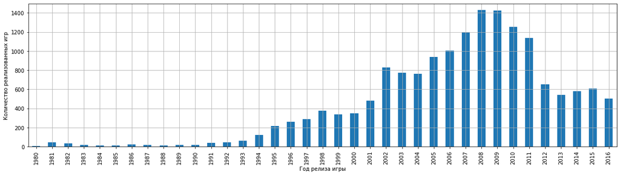

```python
df.pivot_table(index = 'Year_of_Release', values = 'Name', aggfunc = 'count').reset_index().plot(y = 'Name',
x = 'Year_of_Release', kind = 'bar', figsize = (20, 5), legend = False, grid = True)
plt.ylabel('Количество реализованных игр')
plt.xlabel('Год релиза игры')
plt.show()
```

Как видно, подъём в выпуске игр приходится на 1994 год. До этого года игры выпускались досаточно вяло, однако на тот момент игровая индустрия не получила такого широкого развития - технологии и возможности не позволяли. Очевидный пик в развитии игровой индустрии пришёлся на 2000-2011 годы, что неудивительно, так как именно в эти годы было выпущено много шедевров, известных и по сей день: Ведьмак, WarCraft, третьи Герои, Dragon Age Origins, NFS Most Wanted и др.

С 2012 года наблюдается некоторое снижение количества реализованных игр: многие компании-разработчики сместили акцент с количества на качество, не остался в стороне и экономический кризис, заставший мировую экономику в эти годы.

Количество реализованных игр в 2016 году - последнем в нашей выборке - находится на уровне 2001 года, однако мы знаем, что за 2016 год данные могут быть неполными, поэтому ситуация неоднозначная: вдруг здесь только первый месяц 2016 года, и он нам ещё покажет, как продавать надо?

За все периоды данные не нужны: в анализе вполне можно отталкиваться от 2000 года, когда количество выпущенных игр практически из года в год начало расти.

## Этап 3.2. Ответ на вопрос "Как менялись продажи по платформам? За какой характерный срок появляются новые и исчезают старые платформы?".

Чтобы ответить на первый вопрос, воспользуемся сводной таблицей: сгруппируем наши данные по платформе и дате релиза игры, в качестве значения будем использовать совокупные продажи, агрегирующая функция - sum. Результаты визуализируем с помощью гистограммы: по оси x отложим год релиза игры, по оси y - суммарный объём продаж.

Отмечу, что перед использованием сводной таблицы df будет ограничен по полю Platform, чтобы исследовать 1 платформу за раз, а также мы будем рассматривать игры с датой релиза равной или старше 2000, так как на прошлом этапе мы определили, что для анализа целесообразно использовать данные с 2000 года и до последних имеющихся в наличии сведений.

Для автоматизации построения графиков воспользуемся циклом.

Введём список platforms, в котором будут храниться уникальные наименования платформ, для которых выходили игры с датой релиза равной или старше 2000 года. Соответственно, при работе цикла будем перебирать платформы из этого списка.

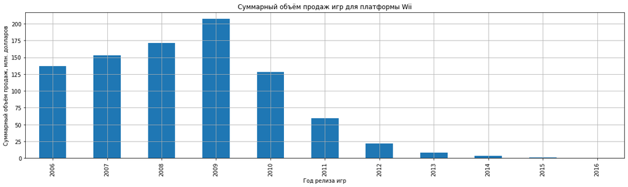

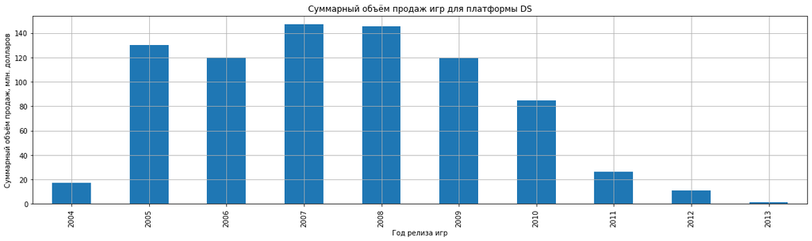

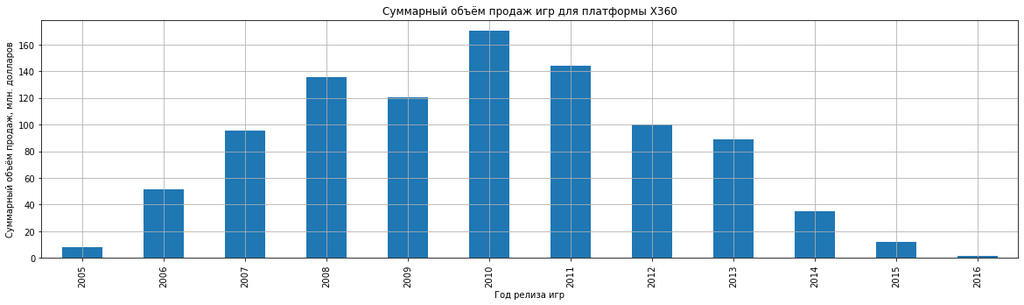

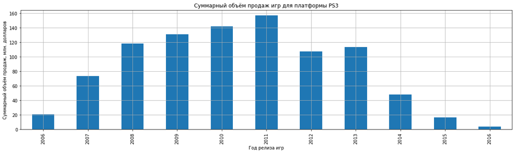

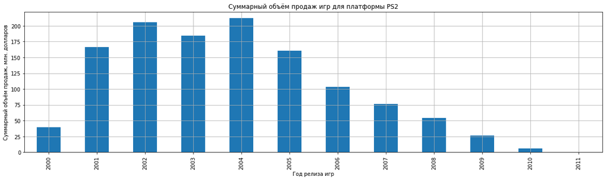

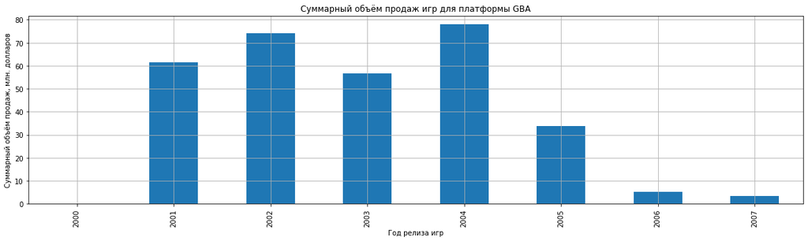

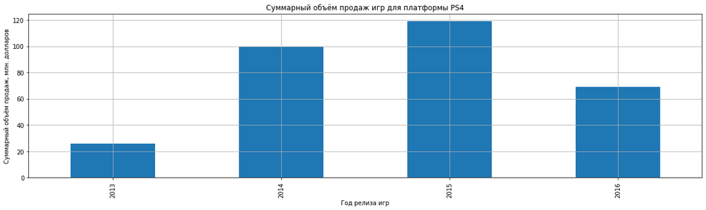

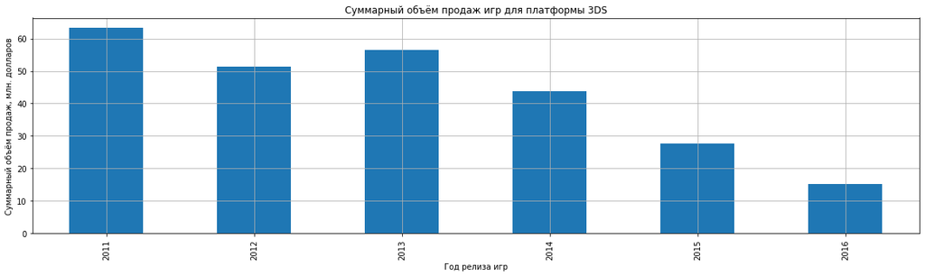

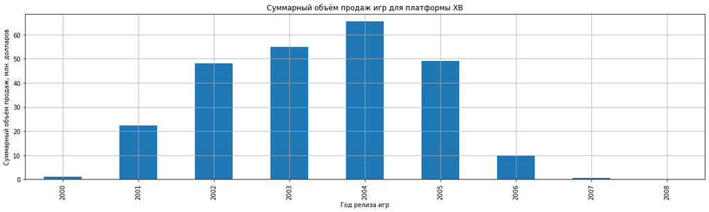

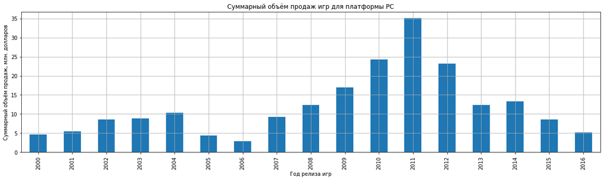

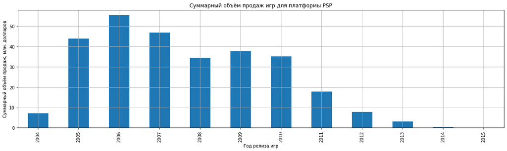

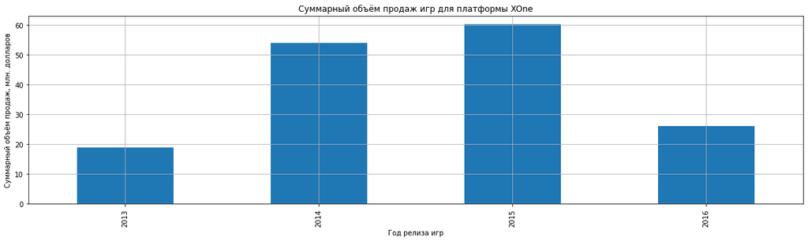

[8 more figures not shown]

```python
platforms = list(df[df['Year_of_Release'] >= 2000]['Platform'].unique())
for platform in platforms:
    df[(df['Platform'] == platform) & (df['Year_of_Release'] >= 2000)].pivot_table(index = ['Platform', 'Year_of_Release'],
    values = 'Total_sales', aggfunc = 'sum').reset_index().plot(y = 'Total_sales', x = 'Year_of_Release',
    kind = 'bar', grid = True,
    legend = False, figsize = (20, 5))
    plt.title('Суммарный объём продаж игр для платформы ' + str(platform))
    plt.xlabel('Год релиза игр')
    plt.ylabel('Суммарный объём продаж, млн. долларов')
    plt.show()
```

Динамика продаж от пратформы к платформе в основном подчиняется закону цикличного развития экономических явлений: любая экономика переживает спад, депрессию, оживление и рост.

А наша компания - это маленькая экономика.

Из имеющихся данных видно, что каждая платформа так или иначе пережила фразу подъёма, и теперь продажи по каждой платформе снижаются.

Из графиков видно, что в среднем стадия оживления и подъёма занимает 5 лет, на 6 году и дальше наблюдается падение продаж. Особенно хорошо данная цикличность видна на граифке продаж игр для платформы PC.

Отобразим его отдельно. При этом уберём ограничение по дате релига игр, равной или старше 2000 года, чтобы оценить весь цикл развития продаж для платформы PC.

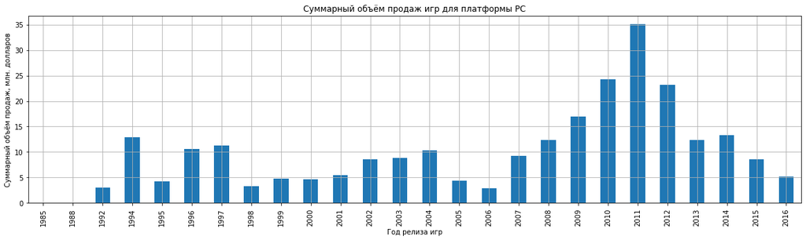

```python
df[df['Platform'] == "PC"].pivot_table(index = ['Platform', 'Year_of_Release'],
values = 'Total_sales', aggfunc = 'sum').reset_index().plot(y = 'Total_sales', x = 'Year_of_Release',
kind = 'bar', grid = True,
legend = False, figsize = (20, 5))
plt.title('Суммарный объём продаж игр для платформы PC')
plt.xlabel('Год релиза игр')
plt.ylabel('Суммарный объём продаж, млн. долларов')
plt.show()
```

На графике мы видим, что продажи упали в 1995 году после роста с 1992 года, далее до 1997 наблюадался рост продаж, который упал в 1998 году. С тех пор - с 1999 года - мы видим последовательный рост объёма продаж вплоть до 2004 года (6 лет), затем - с 2005 года по 2006 год - наблюдается падение продаж, в 2006 году - оживление, далее - с 2007 года по 2011 год - стабильный рост продаж. С 2012 года продажи снова начали падать.

Динамика продаж игр для PC наглядно демонстрирует цикличность в развитии этого сегмента рынка и подтверждает гипотезу о том, что в жизненом цикле платформы на стадию роста в среднем приходится 5 лет.

Однако нам нужно определить длительность самого жизненного цикла платформы.

Чтобы это сделать, сгруппируем наши данные по платформе и дате релиза игры, для каждой из них определим год первого и последнего релиза игры, а также найдём разницу между этими датами.

```python
df_year_of_release = df.groupby('Platform').agg({'Year_of_Release' : ['min', 'max'], 'Total_sales' : ['sum']}).reset_index()
df_year_of_release.columns = ['Platform', 'Min_date', 'Max_date', 'Total_sales']
df_year_of_release['Dif_Date'] = df_year_of_release['Max_date'] - df_year_of_release['Min_date']
df_year_of_release.sort_values('Dif_Date')
```

|  | Platform | Min_date | Max_date | Total_sales | Dif_Date |
| --- | --- | --- | --- | --- | --- |
| 9 | GG | 1992 | 1992 | 0.04 | 0 |
| 14 | PCFX | 1996 | 1996 | 0.03 | 0 |
| 24 | TG16 | 1995 | 1995 | 0.16 | 0 |
| 1 | 3DO | 1994 | 1995 | 0.10 | 1 |
| 22 | SCD | 1993 | 1994 | 1.86 | 1 |
| 25 | WS | 1999 | 2001 | 1.42 | 2 |
| 12 | NG | 1993 | 1996 | 1.44 | 3 |
| 30 | XOne | 2013 | 2016 | 159.32 | 3 |
| 18 | PS4 | 2013 | 2016 | 314.14 | 3 |
| 8 | GEN | 1990 | 1994 | 28.35 | 4 |
| 27 | WiiU | 2012 | 2016 | 82.19 | 4 |
| 20 | PSV | 2011 | 2016 | 53.81 | 5 |
| 2 | 3DS | 2011 | 2016 | 257.81 | 5 |
| 21 | SAT | 1994 | 1999 | 33.59 | 5 |
| 10 | N64 | 1996 | 2002 | 218.01 | 6 |
| 7 | GC | 2001 | 2007 | 196.73 | 6 |
| 6 | GBA | 2000 | 2007 | 312.88 | 7 |
| 29 | XB | 2000 | 2008 | 251.57 | 8 |
| 23 | SNES | 1990 | 1999 | 200.04 | 9 |
| 0 | 2600 | 1980 | 1989 | 86.48 | 9 |
| 15 | PS | 1994 | 2003 | 727.58 | 9 |
| 17 | PS3 | 2006 | 2016 | 931.34 | 10 |
| 26 | Wii | 2006 | 2016 | 891.18 | 10 |
| 3 | DC | 1998 | 2008 | 15.95 | 10 |
| 16 | PS2 | 2000 | 2011 | 1233.56 | 11 |
| 11 | NES | 1983 | 1994 | 251.05 | 11 |
| 28 | X360 | 2005 | 2016 | 961.24 | 11 |
| 19 | PSP | 2004 | 2015 | 289.53 | 11 |
| 5 | GB | 1988 | 2001 | 254.43 | 13 |
| 4 | DS | 1985 | 2013 | 802.78 | 28 |
| 13 | PC | 1985 | 2016 | 255.76 | 31 |

В данной таблице в поле Dif_Date указана длительность жизненного цикла каждой из платформ. Отмечу, что платформы, у которых жизненный цикл равен 0, вероятно, не получили широкого спроса и не развивались за нецелесообразностью.

Визуализируем жизненный цикл платформ.

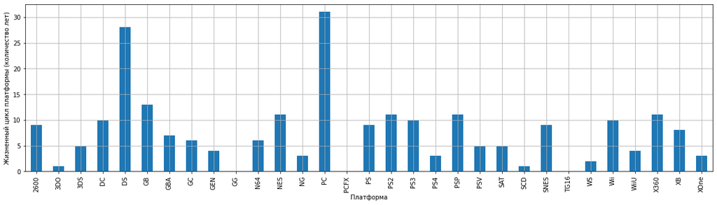

```python
df_year_of_release.plot(x = 'Platform', y = 'Dif_Date', kind = 'bar', legend = False, figsize = (20, 5), grid = True)
plt.xlabel('Платформа')
plt.ylabel('Жизненный цикл платформы (количество лет)')
plt.show()
```

```python
print('Средний жизненный цикл платформы:', round(df_year_of_release['Dif_Date'].mean(), 1), 'лет')
```

```
Средний жизненный цикл платформы: 7.6 лет
```

Из проведённого исследования видно, что в среднем жизненный цикл платформы длится около 7,6 лет, что в целом увязывается с общеизвестным фактом, что платформа, в среднем, живёт в диапазоне от 5 до 10 лет в зависимости от её качества, удобства использования и количества/качества игр, которые для этой платформы выходят.

При этом, как мы видели на ранних графиках, когда исследовали динамику продаж игр в зависимости от платформы, отмечу, что при средней длительности периода жизни платформы в 7.6 лет около 5 из них приходятся на стадии оживления и подъёма, а на 2-3 года - на стадии спада и депрессии. Это также подтверждалось на этапе исследования динамики продаж.

Однако в любом правиле есть и исключения: PS и XBox получают игры более 10 лет, а культовый PC на плаву более трёх десятков лет, и то ли ещё будет.

## Этап 3.3. Ответ на вопрос "Как определить актуальный период, пригодный для построения прогноза на 2017 год?".

Собственно, этот период мы определили ранее: так как жизненный цикл платформы в среднем составляет 8 лет, из которых 5 приходится на фазу ожидавления и роста, а 3 года - на спад и депрессию, актуальным периодом для анализа будем считать 8 лет. Анализируя продажи за 8 лет, мы сможем понять, на каком этапе жизненного цикла находится плафторма.

## Этап 3.4. Ответ на вопрос "Какие платформы лидируют по продажам, растут или падают? Можно ли выбрать несколько потенциально прибыльных платформ?".

На этапе 3.3.2. мы выяснили, что каждая платформа так или иначе находится на этапе спада, когда тх уровень продаж падает. Последняя дата релиза игр - 2016 год, однако для многих из платформ продажи закончили на более ранних этапах.

Чтобы выявить несколько потцениально прибыльных платформ, посмотрим на их суммарные продажи за средний жизненный цикл платформы, т.е. за 8 лет. Соответственно, данные будем брать с 2008 года по 2016 год - этот период соответствует среднему жизненому циклу платформы, который мы определили на этапе 3.3.2.

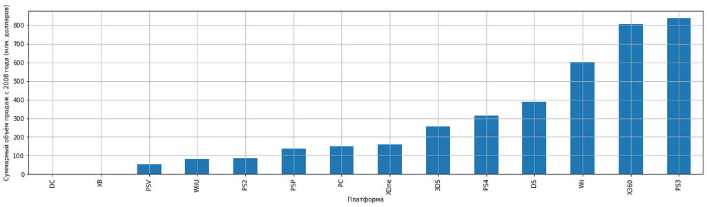

```python
df[df['Year_of_Release'] >= 2008].pivot_table(index = 'Platform', values = 'Total_sales', aggfunc = 'sum').reset_index()\
.sort_values('Total_sales')\
.plot(x = 'Platform', y = 'Total_sales', kind = 'bar', grid = True, legend = False, figsize = (20, 5))
plt.xlabel('Платформа')
plt.ylabel('Суммарный объём продаж с 2008 года (млн. долларов)')
plt.show()
```

На данном графике мы видим суммарные продажи по платформам, начиная с 2008 года. Данный график может ответить на один из извечных вопросов - "что же в фаворе: PC или консоль?". В целом мы видим, что игры для консолей продаются лучше, чем игры на PC.

Однако чтобы выделить перспективные платформы, одной информации о продажах с 2008 года мало: платформа могла пережить свой золотой период за несколько лет с 2008 года и стать неактуальной.

А именно актуальность платформы проверим наличие для платформы игр, выпущенных в 2016 году: если игры для платформы выпускаются и в 2016 году, значит, платформа не утратила свою актуальность и может представлять ценность для прогноза. Напротив, платформы с высокими ранее продажами, но неактуальные на 2016 год, вряд ли будут иметь ценность для прогноза на 2017 год.

Для начала соберём в список наименования платформ, по которым мы смотрели суммарные продажи.

```python
platroms_after_2008 = list(df[df['Year_of_Release'] >= 2008]['Platform'].unique())
len(platroms_after_2008)
```

```
14
```

Таких платформ получилось 14.

Затем соберём в список все аткуальные платформы, т.е. те платформы, для которых в 2016 году ещё выпускаются игры.

```python
actual_platforms_in_2016 = list(df[df['Year_of_Release'] == 2016]['Platform'].unique())
len(actual_platforms_in_2016)
```

```
9
```

А вот актуальных платформ уже 9.

Очевидно, что потцениально прибыльные платформы, для которых можно строить прогнозы - это платформы из списка platroms_after_2008, которые также содержатся в списке actual_platforms_in_2016.

Чтобы определить перечень потенциально прибыльных платформ, создадим список actual_platforms и поместим в него те значения из списка platroms_after_2008, которые есть в списке actual_platforms_in_2016.

Используем цикл.

```python
actual_platforms = []
for i in platroms_after_2008:
    if i in actual_platforms_in_2016:
        actual_platforms.append(i)
        print('Платформа ' + str(i) + ' актуальна')
    else:
        print('Платформа ' + str(i) + ' неактуальна')
```

```
Платформа Wii актуальна
Платформа X360 актуальна
Платформа PS3 актуальна
Платформа DS неактуальна
Платформа PS4 актуальна
Платформа 3DS актуальна
Платформа PC актуальна
Платформа XOne актуальна
Платформа WiiU актуальна
Платформа PSP неактуальна
Платформа PS2 неактуальна
Платформа PSV актуальна
Платформа XB неактуальна
Платформа DC неактуальна
```

Таким образом мы получили список actual_platforms, в котором содержатся только подходящие для прогноза платформы, а именно - платформы:

1. Платформы, для которых есть продажи с 2008 года.
2. Платформы, для которых в 2016 году всё ещё выпускаются игры.

Посмотрим на эти платформы.

```python
actual_platforms
```

```
['Wii', 'X360', 'PS3', 'PS4', '3DS', 'PC', 'XOne', 'WiiU', 'PSV']
```

```python
len(actual_platforms)
```

```
9
```

Видим, что актуальными можно считать 9 платформ из 14.

Данные по остальным платформам можно не анализировать, поэтому удалим их из df.

```python
for i in list(df['Platform'].unique()):
    if i not in actual_platforms:
        df = df[df['Platform'] != i]
```

Проверим, какие уникальные наименования платформ остались в df, чтобы понять, всё ли сделано верно.

```python
print(*list(df['Platform'].unique()))
```

```
Wii X360 PS3 PS4 3DS PC XOne WiiU PSV
```

Видим, что мы довольно успешно убрали из df информацию о неактуальных для нас платформ.

Для оставшихся платформ постром ящик с усами и посмотрим, что сможем сказать на основе этих графиков.

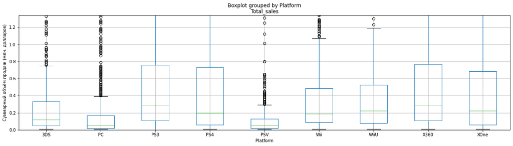

```python
df.boxplot(column = 'Total_sales', by = 'Platform', figsize = (20, 5))
plt.ylabel('Суммарный объём продаж (млн. долларов)')
plt.ylim(0, df['Total_sales'].quantile(0.90))
plt.show()
```

На всех ящиках с усами мы видим одинаковую картину: медиана внутри ящика скошена в левую сторону (или к нижней части оси y), что также вписывается в картину определённого жизненного цикла платформы.

Напомню, что он составляет, в среднем, 8 лет, из которых 5 лет приходится на рост, 3 года - на спад.

Скошенность медианы очевидно обусловлена несбалансированностью жизненного цикла: так как в течение 3 лет продажи падают, а затем в течение 5 лет растут, прибыль, полученная на этапе роста, может быть расценена как выброс относительно всего цикла продаж, в котром есть также низкие продажи из этапа падения.

Очевидно также, что пик продаж (4-5 год на стадии роста) на данных графиков всегда оценивается как выбросы.

## Этап 3.5. Ответ на вопрос "Как влияют на продажи внутри одной популярной платформы отзывы пользователей и критиков? Как можно соотнести полученные выводы с продажами игр на других платформах?".

Чтобы ответить на этот вопрос, сначала определимся, какую платформу будем исследовать.

На этапе 3.3.4. мы исследовали суммарные продажи по платформам с 2008 года, и наибольший объём продаж был замечен за платформой PS3 (Ваш покорный слуга, как фанат PC, тяжко вздохнул).

Поэтому исследовать будем именно PS3. Для анализа зависимости будем использовать диаграмму рассеяния и коэффициенты корреляции.

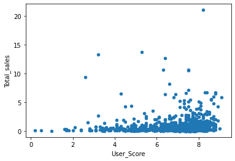

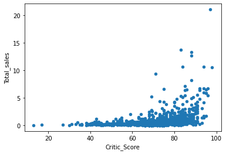

```python
df[df['Platform'] == 'PS3'].plot(x = 'User_Score', y = 'Total_sales', kind = 'scatter')
df[df['Platform'] == 'PS3'].plot(x = 'Critic_Score', y = 'Total_sales', kind = 'scatter')
plt.show()
```

Построим эти диаграммы заново, но уже без выбросов.

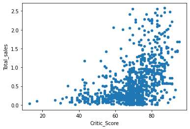

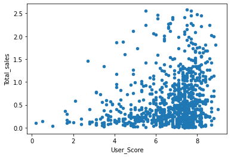

```python
df[(df['Platform'] == 'PS3') & (df['Total_sales'] <= df[df['Platform'] == 'PS3']['Total_sales'].quantile(0.95))].\
plot(x = 'Critic_Score', y = 'Total_sales', kind = 'scatter')
df[(df['Platform'] == 'PS3') & (df['Total_sales'] <= df[df['Platform'] == 'PS3']['Total_sales'].quantile(0.95))].\
plot(x = 'User_Score', y = 'Total_sales', kind = 'scatter')
plt.show()
```

Теперь лучше. Видим, что оценки - как критиков, так и игроков - не оказывают значительного влияния на суммарные продажи: например, значительная часть продаж лежит в диапазоне от 0.0 млн. долларов до 0.5 млн. долларов, однако для игр, формировавших эти продажи, оценки лежат в разном диапазоне - от очень высоких до очень низких.

Поэтому рабочая гипотеза - оценки не влияют на объёмы продаж.

Чтобы закрепить гипотезу, посчитаем коэффициенты корреляции.

```python
df[(df['Platform'] == 'PS3') & (df['Total_sales'] <= df[df['Platform'] == 'PS3']['Total_sales'].quantile(0.95))]\
[['Critic_Score', 'User_Score', 'Total_sales']].corr().tail(1)
```

|  | Critic_Score | User_Score | Total_sales |
| --- | --- | --- | --- |
| Total_sales | 0.410196 | 0.087413 | 1.0 |

Так как значения коэффициента корреляции между изучаемыми признаками всегда больше нуля, можно говорить о том, что линейная зависимость - какой бы сильной она ни была - имеет прямую направленность, т.е. по мере росто какого-либо из признаков будет расти и суммарный объём продаж.

В своей практике я применяю следующую систему критериев оценки силы линейной зависимости:

- линейная зависимость сильная, если значение коэффициента корреляции лежит в пределах от ±0.70 до ±1.00;
- линейная зависимость средняя, если значение коэффициента корреляции лежит в пределах от ±0.30 до ±0.69;
- линейная зависимость слабая, если значение коэффициента корреляции лежит в пределах от 0.00 до ±0.29.

Полученные нами значения коэффициента корреляции предлагаю интерпретировать таким же образом.

Так, зависимость между:

- суммарным объёмом продаж и оценкой критиков - средняя прямая;
- суммарным объёмом продаж и оценкой игроков - низкая прямая.

Отмечу также, что коэффициент корреляции не позволяет доподлинно утверждать о наличии или отсутствии зависимости между изучаемыми показателями, а лишь показывает наличие или отсутствие линейной связи между показателями, а также тесноту этой связи, в рамках изучаемой выборки.

Так, коэффициент корреляции указал на среднюю зависимость между суммарными продажами и оценками критиков и низкую зависимость между суммарными продажами и оценками пользователей.

Посмотрим, справедливы ли данные выводы для других платформ.

```python
print()
for i in list(df['Platform'].unique()):
    print('Зависимость суммарных продаж от оценки критиков/игроков для платформы ' + str(i))
    display(df[(df['Platform'] == i) & (df['Total_sales'] <= df[df['Platform'] == i]['Total_sales'].quantile(0.95))]\
    [['Critic_Score', 'User_Score', 'Total_sales']].corr().tail(1))
    print()
```

```
Зависимость суммарных продаж от оценки критиков/игроков для платформы Wii
```

|  | Critic_Score | User_Score | Total_sales |
| --- | --- | --- | --- |
| Total_sales | 0.086635 | 0.023516 | 1.0 |

```
Зависимость суммарных продаж от оценки критиков/игроков для платформы X360
```

|  | Critic_Score | User_Score | Total_sales |
| --- | --- | --- | --- |
| Total_sales | 0.413268 | 0.098922 | 1.0 |

```
Зависимость суммарных продаж от оценки критиков/игроков для платформы PS3
```

|  | Critic_Score | User_Score | Total_sales |
| --- | --- | --- | --- |
| Total_sales | 0.410196 | 0.087413 | 1.0 |

```
Зависимость суммарных продаж от оценки критиков/игроков для платформы PS4
```

|  | Critic_Score | User_Score | Total_sales |
| --- | --- | --- | --- |
| Total_sales | 0.363961 | -0.053476 | 1.0 |

```
Зависимость суммарных продаж от оценки критиков/игроков для платформы 3DS
```

|  | Critic_Score | User_Score | Total_sales |
| --- | --- | --- | --- |
| Total_sales | 0.109215 | 0.000183 | 1.0 |

```
Зависимость суммарных продаж от оценки критиков/игроков для платформы PC
```

|  | Critic_Score | User_Score | Total_sales |
| --- | --- | --- | --- |
| Total_sales | 0.279814 | -0.005824 | 1.0 |

```
Зависимость суммарных продаж от оценки критиков/игроков для платформы XOne
```

|  | Critic_Score | User_Score | Total_sales |
| --- | --- | --- | --- |
| Total_sales | 0.409323 | -0.079016 | 1.0 |

```
Зависимость суммарных продаж от оценки критиков/игроков для платформы WiiU
```

|  | Critic_Score | User_Score | Total_sales |
| --- | --- | --- | --- |
| Total_sales | 0.272029 | 0.272494 | 1.0 |

```
Зависимость суммарных продаж от оценки критиков/игроков для платформы PSV
```

|  | Critic_Score | User_Score | Total_sales |
| --- | --- | --- | --- |
| Total_sales | 0.108169 | -0.134223 | 1.0 |

## Этап 3.6. Ответ на вопрос "Что можно сказать об общем распределении игр по жанрам? Что можно сказать о самых прибыльных жанрах? Выделяются ли жанры с высокими и низкими продажами?".

Для ответа на первый вопрос воспользуемся сводной таблицей. Результаты визуализируем.

```python
df.pivot_table(index = 'Genre', values = 'Name', aggfunc = 'count').sort_values('Name')
```

| Genre | Name |
| --- | --- |
| Puzzle | 115 |
| Platform | 200 |
| Fighting | 247 |
| Strategy | 293 |
| Simulation | 314 |
| Racing | 403 |
| Adventure | 442 |
| Role-Playing | 574 |
| Shooter | 660 |
| Misc | 678 |
| Sports | 868 |
| Action | 1714 |

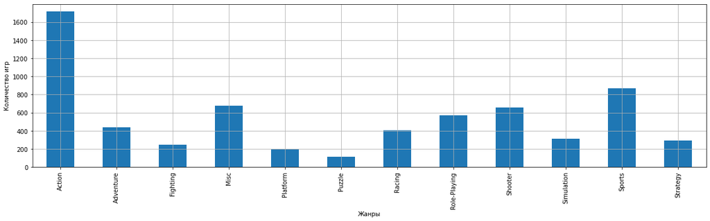

```python
df.pivot_table(index = 'Genre', values = 'Name', aggfunc = 'count').reset_index().plot(y = 'Name', x = 'Genre', kind = 'bar',
legend = False, grid = True, figsize = (20, 5))
plt.xlabel('Жанры')
plt.ylabel('Количество игр')
plt.show()
```

Самым популярным жанром оказался жарн Action (мне он тоже больше всех представленных нравится, кстати). А вот жанр Puzzle, напротив, оказался самым невостребованным.

Теперь посмотрим не на количество игр в определённых жанрах, а на их прибыльность.

```python
df.pivot_table(index = 'Genre', values = 'Total_sales', aggfunc = 'sum').sort_values('Total_sales')
```

| Genre | Total_sales |
| --- | --- |
| Puzzle | 24.47 |
| Strategy | 69.78 |
| Adventure | 82.75 |
| Simulation | 141.41 |
| Fighting | 142.49 |
| Platform | 195.18 |
| Racing | 246.53 |
| Role-Playing | 344.78 |
| Misc | 398.45 |
| Sports | 664.15 |
| Shooter | 697.50 |
| Action | 899.30 |

[figure not shown]

```python
df.pivot_table(index = 'Genre', values = 'Total_sales', aggfunc = 'count').reset_index()\
.plot(y = 'Total_sales', x = 'Genre', kind = 'bar', legend = False, grid = True, figsize = (20, 5))
plt.xlabel('Жанры')
plt.ylabel('Суммарный объём продаж (млн. долларов)')
plt.show()
```

Как и в прошлый раз, жанр Action оказался наиболее прибыльным, а жанр Puzzle - наименее прибыльным. Однако внутри этого ящика есть некоторые изменения: например, по популярности жанр Sports шёл сразу за Action, а по прибыльности за жанром Action идёт жанр Shooter.

Вместе с тем можно выделить три самых прибыльных жанра - Action, Sports и Shooter - и три наименее прибыльных жанра - Puzzle, Strategy и Adventure.

# Вывод по этапу 3.

На данном этапе был проведён **анализ данных.**

Напомню, что в рамках этого этапа требовалось ответить на следующие **вопросы:**

1. Сколько игр выпускалось в разные годы. Важны ли данные за все периоды?
1. Как менялись продажи по платформам? За какой характерный срок появляются новые и исчезают старые платформы?
1. Как определить актуальный период, пригодный для построения прогноза на 2017 год.
1. Какие платформы лидируют по продажам, растут или падают? Можно ли выбрать несколько потенциально прибыльных платформ?
1. Как влияют на продажи внутри одной популярной платформы отзывы пользователей и критиков? Как можно соотнести полученные выводы с продажами игр на других платформах?
1. Что можно сказать об общем распределении игр по жанрам? Что можно сказать о самых прибыльных жанрах? Выделяются ли жанры с высокими и низкими продажами?

# Этап 4. Построение портрета пользователя каждого региона.

В рамках данного этапа требуется **определить:**

1. Самые популярные платформы (топ-5) (с описанием различий в долях продаж).
1. Самые популярные жанры (топ-5) (с пояснением разницы).
1. Влияние рейтинга ESRB на продажи в отдельном регионе.

## Этап 4.1. Определение самых популярных платформы (топ-5) (с описанием различий в долях продаж)

Строим сводную таблицу: группируем данные по платформам и считаем объём продаж. При этом нам нужны такие данные для каждого региона.

```python
NA_sales = df.pivot_table(index = 'Platform', values = 'NA_sales', aggfunc = 'sum').reset_index()\
.sort_values('NA_sales', ascending = False)
NA_sales['share'] = round((NA_sales['NA_sales'] / NA_sales['NA_sales'].sum()), 2)
NA_sales.head(5)
```

|  | Platform | NA_sales | share |
| --- | --- | --- | --- |
| 7 | X360 | 595.74 | 0.31 |
| 5 | Wii | 486.87 | 0.26 |
| 2 | PS3 | 390.13 | 0.21 |
| 3 | PS4 | 108.74 | 0.06 |
| 1 | PC | 93.34 | 0.05 |

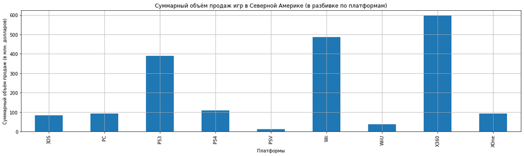

```python
df.pivot_table(index = 'Platform', values = 'NA_sales', aggfunc = 'sum').reset_index()\
.plot(x = 'Platform', y = 'NA_sales', kind = 'bar', grid = True, legend = False, figsize = (20, 5))
plt.xlabel('Платформы')
plt.ylabel('Суммарный объём продаж (в млн. долларов)')
plt.title('Суммарный объём продаж игр в Северной Америке (в разбивке по платформам)')
plt.show()
```

```python
EU_sales = df.pivot_table(index = 'Platform', values = 'EU_sales', aggfunc = 'sum').reset_index()\
.sort_values('EU_sales', ascending = False)
EU_sales['share'] = round((EU_sales['EU_sales'] / EU_sales['EU_sales'].sum()), 2)
EU_sales.head(5)
```

|  | Platform | EU_sales | share |
| --- | --- | --- | --- |
| 2 | PS3 | 327.21 | 0.25 |
| 7 | X360 | 268.32 | 0.21 |
| 5 | Wii | 258.32 | 0.20 |
| 3 | PS4 | 141.09 | 0.11 |
| 1 | PC | 140.37 | 0.11 |

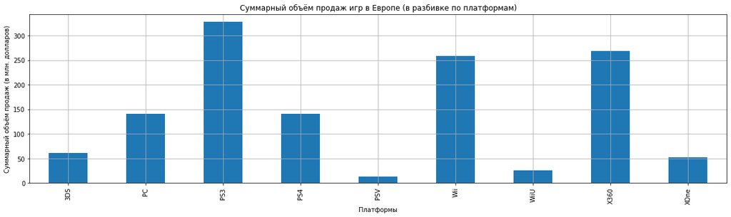

```python
df.pivot_table(index = 'Platform', values = 'EU_sales', aggfunc = 'sum').reset_index()\
.plot(x = 'Platform', y = 'EU_sales', kind = 'bar', grid = True, legend = False, figsize = (20, 5))
plt.xlabel('Платформы')
plt.ylabel('Суммарный объём продаж (в млн. долларов)')
plt.title('Суммарный объём продаж игр в Европе (в разбивке по платформам)')
plt.show()
```

```python
JP_sales = df.pivot_table(index = 'Platform', values = 'JP_sales', aggfunc = 'sum').reset_index()\
.sort_values('JP_sales', ascending = False)
JP_sales['share'] = round((JP_sales['JP_sales'] / JP_sales['JP_sales'].sum()), 2)
JP_sales.head(5)
```

|  | Platform | JP_sales | share |
| --- | --- | --- | --- |
| 0 | 3DS | 100.62 | 0.32 |
| 2 | PS3 | 79.41 | 0.25 |
| 5 | Wii | 68.28 | 0.22 |
| 4 | PSV | 21.84 | 0.07 |
| 3 | PS4 | 15.96 | 0.05 |

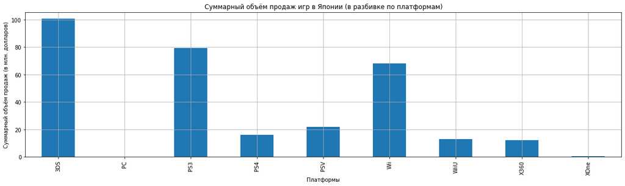

```python
df.pivot_table(index = 'Platform', values = 'JP_sales', aggfunc = 'sum').reset_index()\
.plot(x = 'Platform', y = 'JP_sales', kind = 'bar', grid = True, legend = False, figsize = (20, 5))
plt.xlabel('Платформы')
plt.ylabel('Суммарный объём продаж (в млн. долларов)')
plt.title('Суммарный объём продаж игр в Японии (в разбивке по платформам)')
plt.show()
```

```python
Other_sales = df.pivot_table(index = 'Platform', values = 'Other_sales', aggfunc = 'sum').reset_index()\
.sort_values('Other_sales', ascending = False)
Other_sales['share'] = round((Other_sales['Other_sales'] / Other_sales['Other_sales'].sum()), 2)
Other_sales.head(5)
```

|  | Platform | Other_sales | share |
| --- | --- | --- | --- |
| 2 | PS3 | 134.59 | 0.33 |
| 7 | X360 | 84.88 | 0.21 |
| 5 | Wii | 77.71 | 0.19 |
| 3 | PS4 | 48.35 | 0.12 |
| 1 | PC | 21.88 | 0.05 |

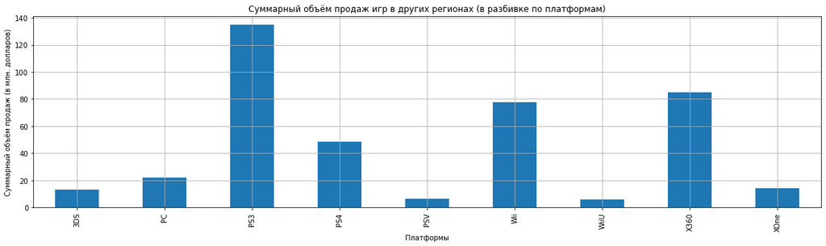

```python
df.pivot_table(index = 'Platform', values = 'Other_sales', aggfunc = 'sum').reset_index()\
.plot(x = 'Platform', y = 'Other_sales', kind = 'bar', grid = True, legend = False, figsize = (20, 5))
plt.xlabel('Платформы')
plt.ylabel('Суммарный объём продаж (в млн. долларов)')
plt.title('Суммарный объём продаж игр в других регионах (в разбивке по платформам)')
plt.show()
```

Для Северной Америки, Европы и других регионов список топ-5 платформ не отличается: он включает такие платформы, как PS3, X360, Wii, PS4 и PC.

Если говорить о менее популярных платформах из топ-5, то для Северной Америки это PC (всплакнул), которая занимает всего около 5% рынка, в Европе - тоже PC (да что ж такое!) с долей рынка в 11%, в других регионах PC тоже не в почёте - около 5% рынка и тоже на дне топ-5 платформ.

Пора пересаживаться на PS3.

А вот в Японии дела обстоят чуть иначе: в Японии в топ-5 платформ входят такие платформы, как 3DS, PS3, Wii, PSV и PS4. Самая популярная - 3DS (даже не слышал о таком), которая занимает 32% рынка, а самой непопулярной из топ-5 платформ является PS4 (ну хоть не PC) с долей рынка 5%.

В целом справедливо сказать, что игроки из разных регионов предпочитают играть и на разных платформах.

## Этап 4.2. Определение самых популярных жанров (топ-5) (с пояснением разницы).

Строим сводную таблицу: группируем данные по жанрам и считаем объём продаж. При этом нам нужны такие данные для каждого региона.

```python
NA_genre_count = df.pivot_table(index = 'Genre', values = 'NA_sales', aggfunc = 'sum').reset_index()\
.sort_values('NA_sales', ascending = False)
NA_genre_count['share'] = round((NA_genre_count['NA_sales'] / NA_genre_count['NA_sales'].sum()), 2)
NA_genre_count.head(5)
```

|  | Genre | NA_sales | share |
| --- | --- | --- | --- |
| 0 | Action | 420.83 | 0.22 |
| 8 | Shooter | 364.62 | 0.19 |
| 10 | Sports | 337.56 | 0.18 |
| 3 | Misc | 222.31 | 0.12 |
| 7 | Role-Playing | 139.70 | 0.07 |

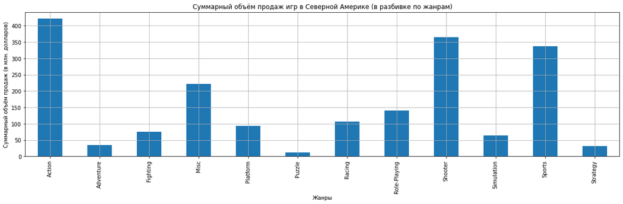

```python
df.pivot_table(index = 'Genre', values = 'NA_sales', aggfunc = 'sum').reset_index()\
.plot(x = 'Genre', y = 'NA_sales', kind = 'bar', grid = True, legend = False, figsize = (20, 5))
plt.xlabel('Жанры')
plt.ylabel('Суммарный объём продаж (в млн. долларов)')
plt.title('Суммарный объём продаж игр в Северной Америке (в разбивке по жанрам)')
plt.show()
```

```python
EU_genre_count = df.pivot_table(index = 'Genre', values = 'EU_sales', aggfunc = 'sum').reset_index()\
.sort_values('EU_sales', ascending = False)
EU_genre_count['share'] = round((EU_genre_count['EU_sales'] / EU_genre_count['EU_sales'].sum()), 2)
EU_genre_count.head(5)
```

|  | Genre | EU_sales | share |
| --- | --- | --- | --- |
| 0 | Action | 303.36 | 0.24 |
| 8 | Shooter | 235.11 | 0.18 |
| 10 | Sports | 225.38 | 0.18 |
| 3 | Misc | 113.40 | 0.09 |
| 6 | Racing | 99.90 | 0.08 |

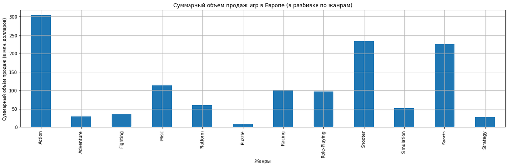

```python
df.pivot_table(index = 'Genre', values = 'EU_sales', aggfunc = 'sum').reset_index()\
.plot(x = 'Genre', y = 'EU_sales', kind = 'bar', grid = True, legend = False, figsize = (20, 5))
plt.xlabel('Жанры')
plt.ylabel('Суммарный объём продаж (в млн. долларов)')
plt.title('Суммарный объём продаж игр в Европе (в разбивке по жанрам)')
plt.show()
```

```python
JP_genre_count = df.pivot_table(index = 'Genre', values = 'JP_sales', aggfunc = 'sum').reset_index()\
.sort_values('JP_sales', ascending = False)
JP_genre_count['share'] = round((JP_genre_count['JP_sales'] / JP_genre_count['JP_sales'].sum()), 2)
JP_genre_count.head(5)
```

|  | Genre | JP_sales | share |
| --- | --- | --- | --- |
| 7 | Role-Playing | 79.22 | 0.25 |
| 0 | Action | 73.02 | 0.23 |
| 10 | Sports | 31.15 | 0.10 |
| 3 | Misc | 26.26 | 0.08 |
| 4 | Platform | 22.58 | 0.07 |

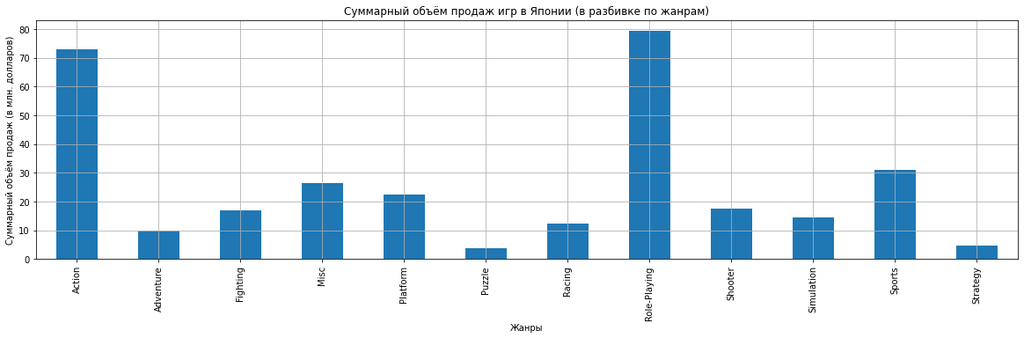

```python
df.pivot_table(index = 'Genre', values = 'JP_sales', aggfunc = 'sum').reset_index()\
.plot(x = 'Genre', y = 'JP_sales', kind = 'bar', grid = True, legend = False, figsize = (20, 5))
plt.xlabel('Жанры')
plt.ylabel('Суммарный объём продаж (в млн. долларов)')
plt.title('Суммарный объём продаж игр в Японии (в разбивке по жанрам)')
plt.show()
```

```python
Other_genre_count = df.pivot_table(index = 'Genre', values = 'Other_sales', aggfunc = 'sum').reset_index()\
.sort_values('Other_sales', ascending = False)
Other_genre_count['share'] = round((Other_genre_count['Other_sales'] / Other_genre_count['Other_sales'].sum()), 2)
Other_genre_count.head(5)
```

|  | Genre | Other_sales | share |
| --- | --- | --- | --- |
| 0 | Action | 102.09 | 0.25 |
| 8 | Shooter | 80.18 | 0.20 |
| 10 | Sports | 70.06 | 0.17 |
| 3 | Misc | 36.48 | 0.09 |
| 7 | Role-Playing | 29.80 | 0.07 |

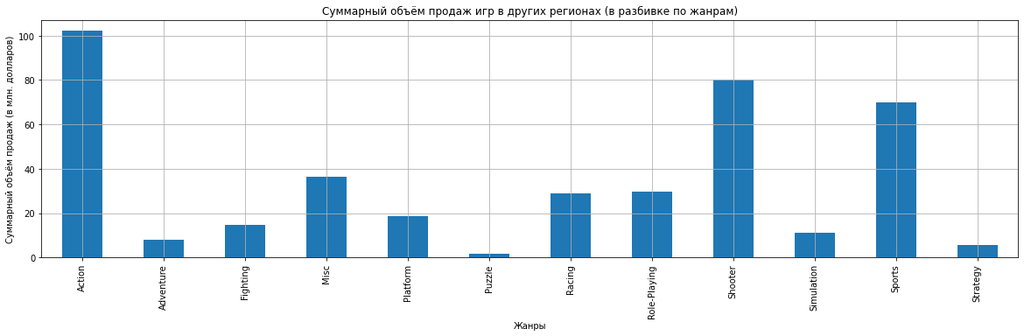

```python
df.pivot_table(index = 'Genre', values = 'Other_sales', aggfunc = 'sum').reset_index()\
.plot(x = 'Genre', y = 'Other_sales', kind = 'bar', grid = True, legend = False, figsize = (20, 5))
plt.xlabel('Жанры')
plt.ylabel('Суммарный объём продаж (в млн. долларов)')
plt.title('Суммарный объём продаж игр в других регионах (в разбивке по жанрам)')
plt.show()
```

Из полученных данных видим, что между игроками из разных регионом существуют различия и в предпочитаемых жанрах.

Так, игроки в Северной Америке, а также в других континентах предпочитают одни и те же жанры: Action, Shooter, Sports, Misc и Role-Playing, при этом их доли на рынке также несильно отличаются:

- Action - 22% и 25% рынка для Северной Америки и других регионов соответственно;
- Shooter - 19% и 20% рынка для Северной Америки и других регионов соответственно;
- Sports - 18% и 17% рынка для Северной Америки и других регионов соответственно;
- Misc - 12% и 9% рынка для Северной Америки и других регионов соответственно;
- Role-Playing - 7% и 7% рынка для Северной Америки и других регионов соответственно.

Почти и не отличишь.

В Европе предпочитают почти те же жанры, разница лишь в том, что вместо жанра Role-Playing в Европе более в ходу игры жанра Racing, хоть они и находятся на последней позиции нашего топ-5 и занимают всего 8% европейского рынка игр. Напротив, Action, как и в Северной Америке и других регионах, возглавляет топ-5 жанров и занимает 24% рынка.

В Японии дела снова обстоят чуть иначе: здесь Action, в отличие от других исследуемых регионов, ценят не так сильно - этот жанр на втором месте с долей рынка в 23%. А вот лидирующую позицию занимает жанр Role-Playing - он захватил четверть японского рынка игр. Меньше всего, судя по нашему топ-5, японцы любят жанр Platform - на его долю приходится всего 7% рынка.

Таким образом, можно утверждать, что популярность жанров от региона к региону отличается незначительно: в топ-5 входят почти одни и те же жанры с небольшим изменением доли рынка от региона к региону.